| title: “U.S. Census Bureau Data Reveals History of Prison Gerrymandering” |
| --- |
| author: “Amanda Hernandez” |
| date: “5/10/2022” |
| output: html_notebook |

```r
library(tidyverse)
library(tidycensus)
library(dplyr)
library(sf)
library(tigris)
```

```r
library(ggplot2)
library(usmap)
library(maps)
census_api_key("8b69f2765f65670c2183febdffce6afc73c72101", install=TRUE, overwrite=TRUE)
```

```
## Your original .Renviron will be backed up and stored in your R HOME directory if needed.
```

```
## Your API key has been stored in your .Renviron and can be accessed by Sys.getenv("CENSUS_API_KEY").
## To use now, restart R or run `readRenviron("~/.Renviron")`
```

```
## [1] "8b69f2765f65670c2183febdffce6afc73c72101"
```

```r
readRenviron("~/.Renviron")
```

### Data Prep & Exploration

Before diving head first into this dataset, it’s important to understand what this data means and what it represents. The dataset, which was downloaded from The Marshall Project’s page on Observable (https://observablehq.com/@themarshallproject/adults-in-correctional-facilities-from-decennial-census), is composed of the number of adults in correctional facilities by county. This population data was collected by the U.S. Census Bureau in 2000, 2010, and 2020.

It’s also important to note that the Census Bureau uses the term “correctional facility” to refer to federal detention centers, federal and state prisons, local jails, correctional residential facilities, and military jails.

When first downloaded and read into RStudio, the dataset will include the following variables or columns:

- state -> State postal codes
- county -> County name
- FIPS -> 6-digit FIPS code for the county
- total_population_20 -> Total population of the county in the 2020 Census
- incarcerated_20 -> Number of incarcerated people in correctional facilities as of the 2020 Census
- total_population_10 -> Total population of the county in the 2010 Census
- incarcerated_10 -> Number of incarcerated people in correctional facilities as of the 2010 Census
- total_population_00 -> Total population of the county in the 2000 Census
- incarcerated_00 -> Number of incarcerated people in correctional facilities as of the 2000 Census

Although these variables are useful on their own, we’ll also add some new ones below. This will help us better understand what potential patterns this data is showing us and how the data as a whole fits together.

```r
incarcerated_pop <- read_csv("data/census_incarceration.csv") %>%
  rename(fips = FIPS) # this standardizes the column names
nrow(incarcerated_pop) # 3211 records
```

```
## [1] 3211
```

```r
ncol(incarcerated_pop) # 9 columns/variables
```

```
## [1] 9
```

```r
# the following code adds columns that display the percent of a county's adult population that's incarcerated and the incarceration rates for 2000, 2010, and 2020

incarcerated_pop <- incarcerated_pop %>%
  mutate(percent_incarcerated_20 = (incarcerated_20/total_population_20)*100) %>%
  mutate(percent_incarcerated_10 = (incarcerated_10/total_population_10)*100) %>%
  mutate(percent_incarcerated_00 = (incarcerated_00/total_population_00)*100)

View(incarcerated_pop)

# the next few lines of code returns a tibble displaying the counties with the highest percentages of incarcerated adult populations in 2020, 2010, and 2020

incarcerated_pop %>%
  arrange(desc(percent_incarcerated_20)) %>%
  select(state, county, percent_incarcerated_20)
```

```
## # A tibble: 3,211 × 3
##    state county                percent_incarcerated_20
##    <chr> <chr>                                   <dbl>
##  1 CO    Crowley County                           48.1
##  2 PA    Forest County                            38.0
##  3 MS    Issaquena County                         36.8
##  4 LA    West Feliciana Parish                    34.5
##  5 GA    Wheeler County                           31.6
##  6 TX    Hudspeth County                          31.1
##  7 TX    Concho County                            30.6
##  8 TX    Garza County                             29.8
##  9 FL    Union County                             29.4
## 10 TN    Lake County                              29.4
## # … with 3,201 more rows
```

```r
# 2020
# CO    Crowley County  48.1256332
# PA    Forest County   38.0467518
# MS    Issaquena County    36.8460389
# LA    West Feliciana Parish   34.5133899
# GA    Wheeler County 31.6155802

incarcerated_pop %>%
  arrange(desc(percent_incarcerated_10)) %>%
  select(state, county, percent_incarcerated_10)
```

```
## # A tibble: 3,211 × 3
##    state county                percent_incarcerated_10
##    <chr> <chr>                                   <dbl>
##  1 CO    Crowley County                           45.6
##  2 TX    Concho County                            38.1
##  3 LA    West Feliciana Parish                    33.1
##  4 CO    Bent County                              32.3
##  5 TX    Garza County                             30.9
##  6 FL    Union County                             30.6
##  7 TN    Lake County                              30.0
##  8 IL    Brown County                             29.7
##  9 VA    Greensville County                       28.6
## 10 PA    Forest County                            28.2
## # … with 3,201 more rows
```

```r
# 2010
# CO    Crowley County  45.6294007
# TX    Concho County   38.0719354
# LA    West Feliciana Parish   33.0944000
# CO    Bent County 32.2818895
# TX    Garza County    30.8775731

incarcerated_pop %>%
  arrange(desc(percent_incarcerated_00)) %>%
  select(state, county, percent_incarcerated_00)
```

```
## # A tibble: 3,211 × 3
##    state county                percent_incarcerated_00
##    <chr> <chr>                                   <dbl>
##  1 CO    Crowley County                           35.4
##  2 LA    West Feliciana Parish                    33.2
##  3 TX    Concho County                            32.8
##  4 FL    Union County                             30.2
##  5 IL    Brown County                             27.5
##  6 TN    Lake County                              26.6
##  7 VA    Greensville County                       26.2
##  8 TX    Mitchell County                          26.1
##  9 CA    Lassen County                            25.5
## 10 TX    Anderson County                          25.5
## # … with 3,201 more rows
```

```r
# 2000
# CO    Crowley County  35.4295034
# LA    West Feliciana Parish   33.2340679
# TX    Concho County   32.7534039
# FL    Union County    30.2112781
# IL    Brown County    27.5107914
```

After exploring the data a bit closer in the code block above, some interesting patterns emerge. Crowley County and West Feliciana Parish, for example, are on every top five list for each year. Also, at least three of the counties in each list are located in the south.

It’s also a bit alarming how high the incarceration rates are. In 2020, roughly 48% of Crowley County’s population was incarcerated. That accounts for almost half of the population.

Let’s look into Crowley County a bit further. According to the U.S. Census Bureau’s quick facts for Crowley County (https://www.census.gov/quickfacts/fact/table/crowleycountycolorado,US/SBO050212), approximately 43.5% of the population is either Black or Hispanic/Latino. In nearby Lincoln County, Black or Hispanic/Latino people make up an even smaller percentage of the population at roughly 20.3%. Based on this alone, it appears that Crowley County is much more diverse than its neighboring counties, and while the Census data may be accurate, it fails to tell a very important story.

The reason why Crowley County’s demographics are so diverse is because almost half of it’s population is incarcerated. In America, minority communities are disproportionately affected by the criminal justice system and face higher incarceration rates compared to white communities.

> “Black Americans are incarcerated in state prisons across the country at nearly five times the rate of whites, and Latinx people are 1.3 times as likely to be incarcerated than non-Latinx whites.” - The Sentencing Project (https://www.sentencingproject.org/publications/color-of-justice-racial-and-ethnic-disparity-in-state-prisons/)

Those incarcerated in Crowley County likely don’t live there. This brings us to the deeply troubling topic of prison gerrymandering. Every 10 years, the U.S. Census Bureau conducts the census to measure changes in population among other important demographic information. When that information is finalized, states and counties begin a process known as redistricting where district/jurisdiction lines are redrawn to be proportional to changes in population.

The issue lies in the fact that redistricting isn’t that simple. Local and state leaders can use Census counts to distort political power and strengthen a particular political party. This alone is known as gerrymandering. Prison gerrymandering, on the other hand, refers to when incarcerated individuals are counted in the states or counties where they are incarcerated instead of where they actually live. This allows state and local leaders to inflate the state or county’s population and political power. It also deprives incarcerated people from proper representation and promotes an inaccurate narrative of how connected incarcerated people are to the communities they are being held in.

> Recommended Reading: “When ‘usual residence’ is a prison” by Jonathan Thompson, High Country News (https://www.hcn.org/issues/52.10/when-usual-residence-is-a-prison)

This is a problem that affects this country nationwide. The high incarceration rates we found in other counties in the code block above are likely also products of prison gerrymandering. Keep this in mind as we continue to navigate through this data and make sense of the patterns that emerge along the way.

As you load each data frame, it might look like there are some strange duplicates under the columns listed above. These duplicates are actually OK to keep. I used these figures to build two other data sets we will use later.

### Creating State Data Frames

```r
# data frames for each state with total pop, total incarcerated, state incarceration rate, percent of state incarcerated (2000-2020)

massachusetts <- subset(incarcerated_pop, state == "MA") %>%
  mutate(total_state_pop_20 = sum(total_population_20)) %>%
  mutate(total_incarcerated_20 = sum(incarcerated_20)) %>%
  mutate(state_incarceration_rate_20 = total_incarcerated_20/total_state_pop_20*100000) %>%
  mutate(total_pct_incarcerated_20 = total_incarcerated_20/total_state_pop_20*100) %>% # 2010 below
  mutate(total_state_pop_10 = sum(total_population_10)) %>%
  mutate(total_incarcerated_10 = sum(incarcerated_10)) %>%
  mutate(state_incarceration_rate_10 = total_incarcerated_10/total_state_pop_10*100000) %>%
  mutate(total_pct_incarcerated_10 = total_incarcerated_10/total_state_pop_10*100) %>% # 2000 below
  mutate(total_state_pop_00 = sum(total_population_00)) %>%
  mutate(total_incarcerated_00 = sum(incarcerated_00)) %>%
  mutate(state_incarceration_rate_00 = total_incarcerated_10/total_state_pop_00*100000) %>%
  mutate(total_pct_incarcerated_00 = total_incarcerated_10/total_state_pop_00*100)

connecticut <- subset(incarcerated_pop, state == "CT") %>%
  mutate(total_state_pop_20 = sum(total_population_20)) %>%
  mutate(total_incarcerated_20 = sum(incarcerated_20)) %>%
  mutate(state_incarceration_rate_20 = total_incarcerated_20/total_state_pop_20*100000) %>%
  mutate(total_pct_incarcerated_20 = total_incarcerated_20/total_state_pop_20*100) %>% # 2010 below
  mutate(total_state_pop_10 = sum(total_population_10)) %>%
  mutate(total_incarcerated_10 = sum(incarcerated_10)) %>%
  mutate(state_incarceration_rate_10 = total_incarcerated_10/total_state_pop_10*100000) %>%
  mutate(total_pct_incarcerated_10 = total_incarcerated_10/total_state_pop_10*100) %>% # 2000 below
  mutate(total_state_pop_00 = sum(total_population_00)) %>%
  mutate(total_incarcerated_00 = sum(incarcerated_00)) %>%
  mutate(state_incarceration_rate_00 = total_incarcerated_10/total_state_pop_00*100000) %>%
  mutate(total_pct_incarcerated_00 = total_incarcerated_10/total_state_pop_00*100)

west_virginia <- subset(incarcerated_pop, state == "WV") %>%
  mutate(total_state_pop_20 = sum(total_population_20)) %>%
  mutate(total_incarcerated_20 = sum(incarcerated_20)) %>%
  mutate(state_incarceration_rate_20 = total_incarcerated_20/total_state_pop_20*100000) %>%
  mutate(total_pct_incarcerated_20 = total_incarcerated_20/total_state_pop_20*100) %>% # 2010 below
  mutate(total_state_pop_10 = sum(total_population_10)) %>%
  mutate(total_incarcerated_10 = sum(incarcerated_10)) %>%
  mutate(state_incarceration_rate_10 = total_incarcerated_10/total_state_pop_10*100000) %>%
  mutate(total_pct_incarcerated_10 = total_incarcerated_10/total_state_pop_10*100) %>% # 2000 below
  mutate(total_state_pop_00 = sum(total_population_00)) %>%
  mutate(total_incarcerated_00 = sum(incarcerated_00)) %>%
  mutate(state_incarceration_rate_00 = total_incarcerated_10/total_state_pop_00*100000) %>%
  mutate(total_pct_incarcerated_00 = total_incarcerated_10/total_state_pop_00*100)

vermont <- subset(incarcerated_pop, state == "VT") %>%
  mutate(total_state_pop_20 = sum(total_population_20)) %>%
  mutate(total_incarcerated_20 = sum(incarcerated_20)) %>%
  mutate(state_incarceration_rate_20 = total_incarcerated_20/total_state_pop_20*100000) %>%
  mutate(total_pct_incarcerated_20 = total_incarcerated_20/total_state_pop_20*100) %>% # 2010 below
  mutate(total_state_pop_10 = sum(total_population_10)) %>%
  mutate(total_incarcerated_10 = sum(incarcerated_10)) %>%
  mutate(state_incarceration_rate_10 = total_incarcerated_10/total_state_pop_10*100000) %>%
  mutate(total_pct_incarcerated_10 = total_incarcerated_10/total_state_pop_10*100) %>% # 2000 below
  mutate(total_state_pop_00 = sum(total_population_00)) %>%
  mutate(total_incarcerated_00 = sum(incarcerated_00)) %>%
  mutate(state_incarceration_rate_00 = total_incarcerated_10/total_state_pop_00*100000) %>%
  mutate(total_pct_incarcerated_00 = total_incarcerated_10/total_state_pop_00*100)

rhode_island <- subset(incarcerated_pop, state == "RI") %>%
  mutate(total_state_pop_20 = sum(total_population_20)) %>%
  mutate(total_incarcerated_20 = sum(incarcerated_20)) %>%
  mutate(state_incarceration_rate_20 = total_incarcerated_20/total_state_pop_20*100000) %>%
  mutate(total_pct_incarcerated_20 = total_incarcerated_20/total_state_pop_20*100) %>% # 2010 below
  mutate(total_state_pop_10 = sum(total_population_10)) %>%
  mutate(total_incarcerated_10 = sum(incarcerated_10)) %>%
  mutate(state_incarceration_rate_10 = total_incarcerated_10/total_state_pop_10*100000) %>%
  mutate(total_pct_incarcerated_10 = total_incarcerated_10/total_state_pop_10*100) %>% # 2000 below
  mutate(total_state_pop_00 = sum(total_population_00)) %>%
  mutate(total_incarcerated_00 = sum(incarcerated_00)) %>%
  mutate(state_incarceration_rate_00 = total_incarcerated_10/total_state_pop_00*100000) %>%
  mutate(total_pct_incarcerated_00 = total_incarcerated_10/total_state_pop_00*100)

washington_dc <- subset(incarcerated_pop, state == "DC") %>%
  mutate(total_state_pop_20 = sum(total_population_20)) %>%
  mutate(total_incarcerated_20 = sum(incarcerated_20)) %>%
  mutate(state_incarceration_rate_20 = total_incarcerated_20/total_state_pop_20*100000) %>%
  mutate(total_pct_incarcerated_20 = total_incarcerated_20/total_state_pop_20*100) %>% # 2010 below
  mutate(total_state_pop_10 = sum(total_population_10)) %>%
  mutate(total_incarcerated_10 = sum(incarcerated_10)) %>%
  mutate(state_incarceration_rate_10 = total_incarcerated_10/total_state_pop_10*100000) %>%
  mutate(total_pct_incarcerated_10 = total_incarcerated_10/total_state_pop_10*100) %>% # 2000 below
  mutate(total_state_pop_00 = sum(total_population_00)) %>%
  mutate(total_incarcerated_00 = sum(incarcerated_00)) %>%
  mutate(state_incarceration_rate_00 = total_incarcerated_10/total_state_pop_00*100000) %>%
  mutate(total_pct_incarcerated_00 = total_incarcerated_10/total_state_pop_00*100)

pennsylvania <- subset(incarcerated_pop, state == "PA") %>%
  mutate(total_state_pop_20 = sum(total_population_20)) %>%
  mutate(total_incarcerated_20 = sum(incarcerated_20)) %>%
  mutate(state_incarceration_rate_20 = total_incarcerated_20/total_state_pop_20*100000) %>%
  mutate(total_pct_incarcerated_20 = total_incarcerated_20/total_state_pop_20*100) %>% # 2010 below
  mutate(total_state_pop_10 = sum(total_population_10)) %>%
  mutate(total_incarcerated_10 = sum(incarcerated_10)) %>%
  mutate(state_incarceration_rate_10 = total_incarcerated_10/total_state_pop_10*100000) %>%
  mutate(total_pct_incarcerated_10 = total_incarcerated_10/total_state_pop_10*100) %>% # 2000 below
  mutate(total_state_pop_00 = sum(total_population_00)) %>%
  mutate(total_incarcerated_00 = sum(incarcerated_00)) %>%
  mutate(state_incarceration_rate_00 = total_incarcerated_10/total_state_pop_00*100000) %>%
  mutate(total_pct_incarcerated_00 = total_incarcerated_10/total_state_pop_00*100)
```

```r
arkansas <- subset(incarcerated_pop, state == "AR") %>%
  mutate(total_state_pop_20 = sum(total_population_20)) %>%
  mutate(total_state_pop_20 = sum(total_population_20)) %>%
  mutate(total_incarcerated_20 = sum(incarcerated_20)) %>%
  mutate(state_incarceration_rate_20 = total_incarcerated_20/total_state_pop_20*100000) %>%
  mutate(total_pct_incarcerated_20 = total_incarcerated_20/total_state_pop_20*100) %>% # 2010 below
  mutate(total_state_pop_10 = sum(total_population_10)) %>%
  mutate(total_incarcerated_10 = sum(incarcerated_10)) %>%
  mutate(state_incarceration_rate_10 = total_incarcerated_10/total_state_pop_10*100000) %>%
  mutate(total_pct_incarcerated_10 = total_incarcerated_10/total_state_pop_10*100) %>% # 2000 below
  mutate(total_state_pop_00 = sum(total_population_00)) %>%
  mutate(total_incarcerated_00 = sum(incarcerated_00)) %>%
  mutate(state_incarceration_rate_00 = total_incarcerated_10/total_state_pop_00*100000) %>%
  mutate(total_pct_incarcerated_00 = total_incarcerated_10/total_state_pop_00*100)

oklahoma <- subset(incarcerated_pop, state == "OK") %>%
  mutate(total_state_pop_20 = sum(total_population_20)) %>%
  mutate(total_incarcerated_20 = sum(incarcerated_20)) %>%
  mutate(state_incarceration_rate_20 = total_incarcerated_20/total_state_pop_20*100000) %>%
  mutate(total_pct_incarcerated_20 = total_incarcerated_20/total_state_pop_20*100) %>% # 2010 below
  mutate(total_state_pop_10 = sum(total_population_10)) %>%
  mutate(total_incarcerated_10 = sum(incarcerated_10)) %>%
  mutate(state_incarceration_rate_10 = total_incarcerated_10/total_state_pop_10*100000) %>%
  mutate(total_pct_incarcerated_10 = total_incarcerated_10/total_state_pop_10*100) %>% # 2000 below
  mutate(total_state_pop_00 = sum(total_population_00)) %>%
  mutate(total_incarcerated_00 = sum(incarcerated_00)) %>%
  mutate(state_incarceration_rate_00 = total_incarcerated_10/total_state_pop_00*100000) %>%
  mutate(total_pct_incarcerated_00 = total_incarcerated_10/total_state_pop_00*100)

nebraska <- subset(incarcerated_pop, state == "NE") %>%
  mutate(total_state_pop_20 = sum(total_population_20)) %>%
  mutate(total_incarcerated_20 = sum(incarcerated_20)) %>%
  mutate(state_incarceration_rate_20 = total_incarcerated_20/total_state_pop_20*100000) %>%
  mutate(total_pct_incarcerated_20 = total_incarcerated_20/total_state_pop_20*100) %>% # 2010 below
  mutate(total_state_pop_10 = sum(total_population_10)) %>%
  mutate(total_incarcerated_10 = sum(incarcerated_10)) %>%
  mutate(state_incarceration_rate_10 = total_incarcerated_10/total_state_pop_10*100000) %>%
  mutate(total_pct_incarcerated_10 = total_incarcerated_10/total_state_pop_10*100) %>% # 2000 below
  mutate(total_state_pop_00 = sum(total_population_00)) %>%
  mutate(total_incarcerated_00 = sum(incarcerated_00)) %>%
  mutate(state_incarceration_rate_00 = total_incarcerated_10/total_state_pop_00*100000) %>%
  mutate(total_pct_incarcerated_00 = total_incarcerated_10/total_state_pop_00*100)

idaho <- subset(incarcerated_pop, state == "ID") %>%
  mutate(total_state_pop_20 = sum(total_population_20)) %>%
  mutate(total_incarcerated_20 = sum(incarcerated_20)) %>%
  mutate(state_incarceration_rate_20 = total_incarcerated_20/total_state_pop_20*100000) %>%
  mutate(total_pct_incarcerated_20 = total_incarcerated_20/total_state_pop_20*100) %>% # 2010 below
  mutate(total_state_pop_10 = sum(total_population_10)) %>%
  mutate(total_incarcerated_10 = sum(incarcerated_10)) %>%
  mutate(state_incarceration_rate_10 = total_incarcerated_10/total_state_pop_10*100000) %>%
  mutate(total_pct_incarcerated_10 = total_incarcerated_10/total_state_pop_10*100) %>% # 2000 below
  mutate(total_state_pop_00 = sum(total_population_00)) %>%
  mutate(total_incarcerated_00 = sum(incarcerated_00)) %>%
  mutate(state_incarceration_rate_00 = total_incarcerated_10/total_state_pop_00*100000) %>%
  mutate(total_pct_incarcerated_00 = total_incarcerated_10/total_state_pop_00*100)

missouri <- subset(incarcerated_pop, state == "MO") %>%
  mutate(total_state_pop_20 = sum(total_population_20)) %>%
  mutate(total_incarcerated_20 = sum(incarcerated_20)) %>%
  mutate(state_incarceration_rate_20 = total_incarcerated_20/total_state_pop_20*100000) %>%
  mutate(total_pct_incarcerated_20 = total_incarcerated_20/total_state_pop_20*100) %>% # 2010 below
  mutate(total_state_pop_10 = sum(total_population_10)) %>%
  mutate(total_incarcerated_10 = sum(incarcerated_10)) %>%
  mutate(state_incarceration_rate_10 = total_incarcerated_10/total_state_pop_10*100000) %>%
  mutate(total_pct_incarcerated_10 = total_incarcerated_10/total_state_pop_10*100) %>% # 2000 below
  mutate(total_state_pop_00 = sum(total_population_00)) %>%
  mutate(total_incarcerated_00 = sum(incarcerated_00)) %>%
  mutate(state_incarceration_rate_00 = total_incarcerated_10/total_state_pop_00*100000) %>%
  mutate(total_pct_incarcerated_00 = total_incarcerated_10/total_state_pop_00*100)

louisiana <- subset(incarcerated_pop, state == "LA") %>%
  mutate(total_state_pop_20 = sum(total_population_20)) %>%
  mutate(total_incarcerated_20 = sum(incarcerated_20)) %>%
  mutate(state_incarceration_rate_20 = total_incarcerated_20/total_state_pop_20*100000) %>%
  mutate(total_pct_incarcerated_20 = total_incarcerated_20/total_state_pop_20*100) %>% # 2010 below
  mutate(total_state_pop_10 = sum(total_population_10)) %>%
  mutate(total_incarcerated_10 = sum(incarcerated_10)) %>%
  mutate(state_incarceration_rate_10 = total_incarcerated_10/total_state_pop_10*100000) %>%
  mutate(total_pct_incarcerated_10 = total_incarcerated_10/total_state_pop_10*100) %>% # 2000 below
  mutate(total_state_pop_00 = sum(total_population_00)) %>%
  mutate(total_incarcerated_00 = sum(incarcerated_00)) %>%
  mutate(state_incarceration_rate_00 = total_incarcerated_10/total_state_pop_00*100000) %>%
  mutate(total_pct_incarcerated_00 = total_incarcerated_10/total_state_pop_00*100)

utah <- subset(incarcerated_pop, state == "UT") %>%
  mutate(total_state_pop_20 = sum(total_population_20)) %>%
  mutate(total_incarcerated_20 = sum(incarcerated_20)) %>%
  mutate(state_incarceration_rate_20 = total_incarcerated_20/total_state_pop_20*100000) %>%
  mutate(total_pct_incarcerated_20 = total_incarcerated_20/total_state_pop_20*100) %>% # 2010 below
  mutate(total_state_pop_10 = sum(total_population_10)) %>%
  mutate(total_incarcerated_10 = sum(incarcerated_10)) %>%
  mutate(state_incarceration_rate_10 = total_incarcerated_10/total_state_pop_10*100000) %>%
  mutate(total_pct_incarcerated_10 = total_incarcerated_10/total_state_pop_10*100) %>% # 2000 below
  mutate(total_state_pop_00 = sum(total_population_00)) %>%
  mutate(total_incarcerated_00 = sum(incarcerated_00)) %>%
  mutate(state_incarceration_rate_00 = total_incarcerated_10/total_state_pop_00*100000) %>%
  mutate(total_pct_incarcerated_00 = total_incarcerated_10/total_state_pop_00*100)
```

```r
arizona <- subset(incarcerated_pop, state == "AZ") %>%
  mutate(total_state_pop_20 = sum(total_population_20)) %>%
  mutate(total_incarcerated_20 = sum(incarcerated_20)) %>%
  mutate(state_incarceration_rate_20 = total_incarcerated_20/total_state_pop_20*100000) %>%
  mutate(total_pct_incarcerated_20 = total_incarcerated_20/total_state_pop_20*100) %>% # 2010 below
  mutate(total_state_pop_10 = sum(total_population_10)) %>%
  mutate(total_incarcerated_10 = sum(incarcerated_10)) %>%
  mutate(state_incarceration_rate_10 = total_incarcerated_10/total_state_pop_10*100000) %>%
  mutate(total_pct_incarcerated_10 = total_incarcerated_10/total_state_pop_10*100) %>% # 2000 below
  mutate(total_state_pop_00 = sum(total_population_00)) %>%
  mutate(total_incarcerated_00 = sum(incarcerated_00)) %>%
  mutate(state_incarceration_rate_00 = total_incarcerated_10/total_state_pop_00*100000) %>%
  mutate(total_pct_incarcerated_00 = total_incarcerated_10/total_state_pop_00*100)

south_carolina <- subset(incarcerated_pop, state == "SC") %>%
  mutate(total_state_pop_20 = sum(total_population_20)) %>%
  mutate(total_incarcerated_20 = sum(incarcerated_20)) %>%
  mutate(state_incarceration_rate_20 = total_incarcerated_20/total_state_pop_20*100000) %>%
  mutate(total_pct_incarcerated_20 = total_incarcerated_20/total_state_pop_20*100) %>% # 2010 below
  mutate(total_state_pop_10 = sum(total_population_10)) %>%
  mutate(total_incarcerated_10 = sum(incarcerated_10)) %>%
  mutate(state_incarceration_rate_10 = total_incarcerated_10/total_state_pop_10*100000) %>%
  mutate(total_pct_incarcerated_10 = total_incarcerated_10/total_state_pop_10*100) %>% # 2000 below
  mutate(total_state_pop_00 = sum(total_population_00)) %>%
  mutate(total_incarcerated_00 = sum(incarcerated_00)) %>%
  mutate(state_incarceration_rate_00 = total_incarcerated_10/total_state_pop_00*100000) %>%
  mutate(total_pct_incarcerated_00 = total_incarcerated_10/total_state_pop_00*100)

georgia <- subset(incarcerated_pop, state == "GA") %>%
  mutate(total_state_pop_20 = sum(total_population_20)) %>%
  mutate(total_incarcerated_20 = sum(incarcerated_20)) %>%
  mutate(state_incarceration_rate_20 = total_incarcerated_20/total_state_pop_20*100000) %>%
  mutate(total_pct_incarcerated_20 = total_incarcerated_20/total_state_pop_20*100) %>% # 2010 below
  mutate(total_state_pop_10 = sum(total_population_10)) %>%
  mutate(total_incarcerated_10 = sum(incarcerated_10)) %>%
  mutate(state_incarceration_rate_10 = total_incarcerated_10/total_state_pop_10*100000) %>%
  mutate(total_pct_incarcerated_10 = total_incarcerated_10/total_state_pop_10*100) %>% # 2000 below
  mutate(total_state_pop_00 = sum(total_population_00)) %>%
  mutate(total_incarcerated_00 = sum(incarcerated_00)) %>%
  mutate(state_incarceration_rate_00 = total_incarcerated_10/total_state_pop_00*100000) %>%
  mutate(total_pct_incarcerated_00 = total_incarcerated_10/total_state_pop_00*100)

tennessee <- subset(incarcerated_pop, state == "TN") %>%
  mutate(total_state_pop_20 = sum(total_population_20)) %>%
  mutate(total_incarcerated_20 = sum(incarcerated_20)) %>%
  mutate(state_incarceration_rate_20 = total_incarcerated_20/total_state_pop_20*100000) %>%
  mutate(total_pct_incarcerated_20 = total_incarcerated_20/total_state_pop_20*100) %>% # 2010 below
  mutate(total_state_pop_10 = sum(total_population_10)) %>%
  mutate(total_incarcerated_10 = sum(incarcerated_10)) %>%
  mutate(state_incarceration_rate_10 = total_incarcerated_10/total_state_pop_10*100000) %>%
  mutate(total_pct_incarcerated_10 = total_incarcerated_10/total_state_pop_10*100) %>% # 2000 below
  mutate(total_state_pop_00 = sum(total_population_00)) %>%
  mutate(total_incarcerated_00 = sum(incarcerated_00)) %>%
  mutate(state_incarceration_rate_00 = total_incarcerated_10/total_state_pop_00*100000) %>%
  mutate(total_pct_incarcerated_00 = total_incarcerated_10/total_state_pop_00*100)

new_york <- subset(incarcerated_pop, state == "NY") %>%
  mutate(total_state_pop_20 = sum(total_population_20)) %>%
  mutate(total_incarcerated_20 = sum(incarcerated_20)) %>%
  mutate(state_incarceration_rate_20 = total_incarcerated_20/total_state_pop_20*100000) %>%
  mutate(total_pct_incarcerated_20 = total_incarcerated_20/total_state_pop_20*100) %>% # 2010 below
  mutate(total_state_pop_10 = sum(total_population_10)) %>%
  mutate(total_incarcerated_10 = sum(incarcerated_10)) %>%
  mutate(state_incarceration_rate_10 = total_incarcerated_10/total_state_pop_10*100000) %>%
  mutate(total_pct_incarcerated_10 = total_incarcerated_10/total_state_pop_10*100) %>% # 2000 below
  mutate(total_state_pop_00 = sum(total_population_00)) %>%
  mutate(total_incarcerated_00 = sum(incarcerated_00)) %>%
  mutate(state_incarceration_rate_00 = total_incarcerated_10/total_state_pop_00*100000) %>%
  mutate(total_pct_incarcerated_00 = total_incarcerated_10/total_state_pop_00*100)

mississippi <- subset(incarcerated_pop, state == "MS") %>%
  mutate(total_state_pop_20 = sum(total_population_20)) %>%
  mutate(total_incarcerated_20 = sum(incarcerated_20)) %>%
  mutate(state_incarceration_rate_20 = total_incarcerated_20/total_state_pop_20*100000) %>%
  mutate(total_pct_incarcerated_20 = total_incarcerated_20/total_state_pop_20*100) %>% # 2010 below
  mutate(total_state_pop_10 = sum(total_population_10)) %>%
  mutate(total_incarcerated_10 = sum(incarcerated_10)) %>%
  mutate(state_incarceration_rate_10 = total_incarcerated_10/total_state_pop_10*100000) %>%
  mutate(total_pct_incarcerated_10 = total_incarcerated_10/total_state_pop_10*100) %>% # 2000 below
  mutate(total_state_pop_00 = sum(total_population_00)) %>%
  mutate(total_incarcerated_00 = sum(incarcerated_00)) %>%
  mutate(state_incarceration_rate_00 = total_incarcerated_10/total_state_pop_00*100000) %>%
  mutate(total_pct_incarcerated_00 = total_incarcerated_10/total_state_pop_00*100)

new_mexico <- subset(incarcerated_pop, state == "NM") %>%
  mutate(total_state_pop_20 = sum(total_population_20)) %>%
  mutate(total_incarcerated_20 = sum(incarcerated_20)) %>%
  mutate(state_incarceration_rate_20 = total_incarcerated_20/total_state_pop_20*100000) %>%
  mutate(total_pct_incarcerated_20 = total_incarcerated_20/total_state_pop_20*100) %>% # 2010 below
  mutate(total_state_pop_10 = sum(total_population_10)) %>%
  mutate(total_incarcerated_10 = sum(incarcerated_10)) %>%
  mutate(state_incarceration_rate_10 = total_incarcerated_10/total_state_pop_10*100000) %>%
  mutate(total_pct_incarcerated_10 = total_incarcerated_10/total_state_pop_10*100) %>% # 2000 below
  mutate(total_state_pop_00 = sum(total_population_00)) %>%
  mutate(total_incarcerated_00 = sum(incarcerated_00)) %>%
  mutate(state_incarceration_rate_00 = total_incarcerated_10/total_state_pop_00*100000) %>%
  mutate(total_pct_incarcerated_00 = total_incarcerated_10/total_state_pop_00*100)
```

```r
illinois <- subset(incarcerated_pop, state == "IL") %>%
  mutate(total_state_pop_20 = sum(total_population_20)) %>%
  mutate(total_incarcerated_20 = sum(incarcerated_20)) %>%
  mutate(state_incarceration_rate_20 = total_incarcerated_20/total_state_pop_20*100000) %>%
  mutate(total_pct_incarcerated_20 = total_incarcerated_20/total_state_pop_20*100) %>% # 2010 below
  mutate(total_state_pop_10 = sum(total_population_10)) %>%
  mutate(total_incarcerated_10 = sum(incarcerated_10)) %>%
  mutate(state_incarceration_rate_10 = total_incarcerated_10/total_state_pop_10*100000) %>%
  mutate(total_pct_incarcerated_10 = total_incarcerated_10/total_state_pop_10*100) %>% # 2000 below
  mutate(total_state_pop_00 = sum(total_population_00)) %>%
  mutate(total_incarcerated_00 = sum(incarcerated_00)) %>%
  mutate(state_incarceration_rate_00 = total_incarcerated_10/total_state_pop_00*100000) %>%
  mutate(total_pct_incarcerated_00 = total_incarcerated_10/total_state_pop_00*100)

michigan <- subset(incarcerated_pop, state == "MI") %>%
  mutate(total_state_pop_20 = sum(total_population_20)) %>%
  mutate(total_incarcerated_20 = sum(incarcerated_20)) %>%
  mutate(state_incarceration_rate_20 = total_incarcerated_20/total_state_pop_20*100000) %>%
  mutate(total_pct_incarcerated_20 = total_incarcerated_20/total_state_pop_20*100) %>% # 2010 below
  mutate(total_state_pop_10 = sum(total_population_10)) %>%
  mutate(total_incarcerated_10 = sum(incarcerated_10)) %>%
  mutate(state_incarceration_rate_10 = total_incarcerated_10/total_state_pop_10*100000) %>%
  mutate(total_pct_incarcerated_10 = total_incarcerated_10/total_state_pop_10*100) %>% # 2000 below
  mutate(total_state_pop_00 = sum(total_population_00)) %>%
  mutate(total_incarcerated_00 = sum(incarcerated_00)) %>%
  mutate(state_incarceration_rate_00 = total_incarcerated_10/total_state_pop_00*100000) %>%
  mutate(total_pct_incarcerated_00 = total_incarcerated_10/total_state_pop_00*100)

maine <- subset(incarcerated_pop, state == "ME") %>%
  mutate(total_state_pop_20 = sum(total_population_20)) %>%
  mutate(total_incarcerated_20 = sum(incarcerated_20)) %>%
  mutate(state_incarceration_rate_20 = total_incarcerated_20/total_state_pop_20*100000) %>%
  mutate(total_pct_incarcerated_20 = total_incarcerated_20/total_state_pop_20*100) %>% # 2010 below
  mutate(total_state_pop_10 = sum(total_population_10)) %>%
  mutate(total_incarcerated_10 = sum(incarcerated_10)) %>%
  mutate(state_incarceration_rate_10 = total_incarcerated_10/total_state_pop_10*100000) %>%
  mutate(total_pct_incarcerated_10 = total_incarcerated_10/total_state_pop_10*100) %>% # 2000 below
  mutate(total_state_pop_00 = sum(total_population_00)) %>%
  mutate(total_incarcerated_00 = sum(incarcerated_00)) %>%
  mutate(state_incarceration_rate_00 = total_incarcerated_10/total_state_pop_00*100000) %>%
  mutate(total_pct_incarcerated_00 = total_incarcerated_10/total_state_pop_00*100)

indiana <- subset(incarcerated_pop, state == "IN") %>%
  mutate(total_state_pop_20 = sum(total_population_20)) %>%
  mutate(total_incarcerated_20 = sum(incarcerated_20)) %>%
  mutate(state_incarceration_rate_20 = total_incarcerated_20/total_state_pop_20*100000) %>%
  mutate(total_pct_incarcerated_20 = total_incarcerated_20/total_state_pop_20*100) %>% # 2010 below
  mutate(total_state_pop_10 = sum(total_population_10)) %>%
  mutate(total_incarcerated_10 = sum(incarcerated_10)) %>%
  mutate(state_incarceration_rate_10 = total_incarcerated_10/total_state_pop_10*100000) %>%
  mutate(total_pct_incarcerated_10 = total_incarcerated_10/total_state_pop_10*100) %>% # 2000 below
  mutate(total_state_pop_00 = sum(total_population_00)) %>%
  mutate(total_incarcerated_00 = sum(incarcerated_00)) %>%
  mutate(state_incarceration_rate_00 = total_incarcerated_10/total_state_pop_00*100000) %>%
  mutate(total_pct_incarcerated_00 = total_incarcerated_10/total_state_pop_00*100)

north_carolina <- subset(incarcerated_pop, state == "NC") %>%
  mutate(total_state_pop_20 = sum(total_population_20)) %>%
  mutate(total_incarcerated_20 = sum(incarcerated_20)) %>%
  mutate(state_incarceration_rate_20 = total_incarcerated_20/total_state_pop_20*100000) %>%
  mutate(total_pct_incarcerated_20 = total_incarcerated_20/total_state_pop_20*100) %>% # 2010 below
  mutate(total_state_pop_10 = sum(total_population_10)) %>%
  mutate(total_incarcerated_10 = sum(incarcerated_10)) %>%
  mutate(state_incarceration_rate_10 = total_incarcerated_10/total_state_pop_10*100000) %>%
  mutate(total_pct_incarcerated_10 = total_incarcerated_10/total_state_pop_10*100) %>% # 2000 below
  mutate(total_state_pop_00 = sum(total_population_00)) %>%
  mutate(total_incarcerated_00 = sum(incarcerated_00)) %>%
  mutate(state_incarceration_rate_00 = total_incarcerated_10/total_state_pop_00*100000) %>%
  mutate(total_pct_incarcerated_00 = total_incarcerated_10/total_state_pop_00*100)

delaware <- subset(incarcerated_pop, state == "DE") %>%
  mutate(total_state_pop_20 = sum(total_population_20)) %>%
  mutate(total_incarcerated_20 = sum(incarcerated_20)) %>%
  mutate(state_incarceration_rate_20 = total_incarcerated_20/total_state_pop_20*100000) %>%
  mutate(total_pct_incarcerated_20 = total_incarcerated_20/total_state_pop_20*100) %>% # 2010 below
  mutate(total_state_pop_10 = sum(total_population_10)) %>%
  mutate(total_incarcerated_10 = sum(incarcerated_10)) %>%
  mutate(state_incarceration_rate_10 = total_incarcerated_10/total_state_pop_10*100000) %>%
  mutate(total_pct_incarcerated_10 = total_incarcerated_10/total_state_pop_10*100) %>% # 2000 below
  mutate(total_state_pop_00 = sum(total_population_00)) %>%
  mutate(total_incarcerated_00 = sum(incarcerated_00)) %>%
  mutate(state_incarceration_rate_00 = total_incarcerated_10/total_state_pop_00*100000) %>%
  mutate(total_pct_incarcerated_00 = total_incarcerated_10/total_state_pop_00*100)

texas <- subset(incarcerated_pop, state == "TX") %>%
  mutate(total_state_pop_20 = sum(total_population_20)) %>%
  mutate(total_incarcerated_20 = sum(incarcerated_20)) %>%
  mutate(state_incarceration_rate_20 = total_incarcerated_20/total_state_pop_20*100000) %>%
  mutate(total_pct_incarcerated_20 = total_incarcerated_20/total_state_pop_20*100) %>% # 2010 below
  mutate(total_state_pop_10 = sum(total_population_10)) %>%
  mutate(total_incarcerated_10 = sum(incarcerated_10)) %>%
  mutate(state_incarceration_rate_10 = total_incarcerated_10/total_state_pop_10*100000) %>%
  mutate(total_pct_incarcerated_10 = total_incarcerated_10/total_state_pop_10*100) %>% # 2000 below
  mutate(total_state_pop_00 = sum(total_population_00)) %>%
  mutate(total_incarcerated_00 = sum(incarcerated_00)) %>%
  mutate(state_incarceration_rate_00 = total_incarcerated_10/total_state_pop_00*100000) %>%
  mutate(total_pct_incarcerated_00 = total_incarcerated_10/total_state_pop_00*100)
```

```r
alabama <- subset(incarcerated_pop, state == "AL") %>%
  mutate(total_state_pop_20 = sum(total_population_20)) %>%
  mutate(total_incarcerated_20 = sum(incarcerated_20)) %>%
  mutate(state_incarceration_rate_20 = total_incarcerated_20/total_state_pop_20*100000) %>%
  mutate(total_pct_incarcerated_20 = total_incarcerated_20/total_state_pop_20*100) %>% # 2010 below
  mutate(total_state_pop_10 = sum(total_population_10)) %>%
  mutate(total_incarcerated_10 = sum(incarcerated_10)) %>%
  mutate(state_incarceration_rate_10 = total_incarcerated_10/total_state_pop_10*100000) %>%
  mutate(total_pct_incarcerated_10 = total_incarcerated_10/total_state_pop_10*100) %>% # 2000 below
  mutate(total_state_pop_00 = sum(total_population_00)) %>%
  mutate(total_incarcerated_00 = sum(incarcerated_00)) %>%
  mutate(state_incarceration_rate_00 = total_incarcerated_10/total_state_pop_00*100000) %>%
  mutate(total_pct_incarcerated_00 = total_incarcerated_10/total_state_pop_00*100)

california <- subset(incarcerated_pop, state == "CA") %>%
  mutate(total_state_pop_20 = sum(total_population_20)) %>%
  mutate(total_incarcerated_20 = sum(incarcerated_20)) %>%
  mutate(state_incarceration_rate_20 = total_incarcerated_20/total_state_pop_20*100000) %>%
  mutate(total_pct_incarcerated_20 = total_incarcerated_20/total_state_pop_20*100) %>% # 2010 below
  mutate(total_state_pop_10 = sum(total_population_10)) %>%
  mutate(total_incarcerated_10 = sum(incarcerated_10)) %>%
  mutate(state_incarceration_rate_10 = total_incarcerated_10/total_state_pop_10*100000) %>%
  mutate(total_pct_incarcerated_10 = total_incarcerated_10/total_state_pop_10*100) %>% # 2000 below
  mutate(total_state_pop_00 = sum(total_population_00)) %>%
  mutate(total_incarcerated_00 = sum(incarcerated_00)) %>%
  mutate(state_incarceration_rate_00 = total_incarcerated_10/total_state_pop_00*100000) %>%
  mutate(total_pct_incarcerated_00 = total_incarcerated_10/total_state_pop_00*100)

virginia <- subset(incarcerated_pop, state == "VA") %>%
  mutate(total_state_pop_20 = sum(total_population_20)) %>%
  mutate(total_incarcerated_20 = sum(incarcerated_20)) %>%
  mutate(state_incarceration_rate_20 = total_incarcerated_20/total_state_pop_20*100000) %>%
  mutate(total_pct_incarcerated_20 = total_incarcerated_20/total_state_pop_20*100) %>% # 2010 below
  mutate(total_state_pop_10 = sum(total_population_10)) %>%
  mutate(total_incarcerated_10 = sum(incarcerated_10)) %>%
  mutate(state_incarceration_rate_10 = total_incarcerated_10/total_state_pop_10*100000) %>%
  mutate(total_pct_incarcerated_10 = total_incarcerated_10/total_state_pop_10*100) %>% # 2000 below
  mutate(total_state_pop_00 = sum(total_population_00)) %>%
  mutate(total_incarcerated_00 = sum(incarcerated_00)) %>%
  mutate(state_incarceration_rate_00 = total_incarcerated_10/total_state_pop_00*100000) %>%
  mutate(total_pct_incarcerated_00 = total_incarcerated_10/total_state_pop_00*100)

south_dakota <- subset(incarcerated_pop, state == "SD") %>%
  mutate(total_state_pop_20 = sum(total_population_20)) %>%
  mutate(total_incarcerated_20 = sum(incarcerated_20)) %>%
  mutate(state_incarceration_rate_20 = total_incarcerated_20/total_state_pop_20*100000) %>%
  mutate(total_pct_incarcerated_20 = total_incarcerated_20/total_state_pop_20*100) %>% # 2010 below
  mutate(total_state_pop_10 = sum(total_population_10)) %>%
  mutate(total_incarcerated_10 = sum(incarcerated_10)) %>%
  mutate(state_incarceration_rate_10 = total_incarcerated_10/total_state_pop_10*100000) %>%
  mutate(total_pct_incarcerated_10 = total_incarcerated_10/total_state_pop_10*100) %>% # 2000 below
  mutate(total_state_pop_00 = sum(total_population_00)) %>%
  mutate(total_incarcerated_00 = sum(incarcerated_00)) %>%
  mutate(state_incarceration_rate_00 = total_incarcerated_10/total_state_pop_00*100000) %>%
  mutate(total_pct_incarcerated_00 = total_incarcerated_10/total_state_pop_00*100)

montana <- subset(incarcerated_pop, state == "MT") %>%
  mutate(total_state_pop_20 = sum(total_population_20)) %>%
  mutate(total_incarcerated_20 = sum(incarcerated_20)) %>%
  mutate(state_incarceration_rate_20 = total_incarcerated_20/total_state_pop_20*100000) %>%
  mutate(total_pct_incarcerated_20 = total_incarcerated_20/total_state_pop_20*100) %>% # 2010 below
  mutate(total_state_pop_10 = sum(total_population_10)) %>%
  mutate(total_incarcerated_10 = sum(incarcerated_10)) %>%
  mutate(state_incarceration_rate_10 = total_incarcerated_10/total_state_pop_10*100000) %>%
  mutate(total_pct_incarcerated_10 = total_incarcerated_10/total_state_pop_10*100) %>% # 2000 below
  mutate(total_state_pop_00 = sum(total_population_00)) %>%
  mutate(total_incarcerated_00 = sum(incarcerated_00)) %>%
  mutate(state_incarceration_rate_00 = total_incarcerated_10/total_state_pop_00*100000) %>%
  mutate(total_pct_incarcerated_00 = total_incarcerated_10/total_state_pop_00*100)

new_jersey <- subset(incarcerated_pop, state == "NJ") %>%
  mutate(total_state_pop_20 = sum(total_population_20)) %>%
  mutate(total_incarcerated_20 = sum(incarcerated_20)) %>%
  mutate(state_incarceration_rate_20 = total_incarcerated_20/total_state_pop_20*100000) %>%
  mutate(total_pct_incarcerated_20 = total_incarcerated_20/total_state_pop_20*100) %>% # 2010 below
  mutate(total_state_pop_10 = sum(total_population_10)) %>%
  mutate(total_incarcerated_10 = sum(incarcerated_10)) %>%
  mutate(state_incarceration_rate_10 = total_incarcerated_10/total_state_pop_10*100000) %>%
  mutate(total_pct_incarcerated_10 = total_incarcerated_10/total_state_pop_10*100) %>% # 2000 below
  mutate(total_state_pop_00 = sum(total_population_00)) %>%
  mutate(total_incarcerated_00 = sum(incarcerated_00)) %>%
  mutate(state_incarceration_rate_00 = total_incarcerated_10/total_state_pop_00*100000) %>%
  mutate(total_pct_incarcerated_00 = total_incarcerated_10/total_state_pop_00*100)

hawaii <- subset(incarcerated_pop, state == "HI") %>%
  mutate(total_state_pop_20 = sum(total_population_20)) %>%
  mutate(total_incarcerated_20 = sum(incarcerated_20)) %>%
  mutate(state_incarceration_rate_20 = total_incarcerated_20/total_state_pop_20*100000) %>%
  mutate(total_pct_incarcerated_20 = total_incarcerated_20/total_state_pop_20*100) %>% # 2010 below
  mutate(total_state_pop_10 = sum(total_population_10)) %>%
  mutate(total_incarcerated_10 = sum(incarcerated_10)) %>%
  mutate(state_incarceration_rate_10 = total_incarcerated_10/total_state_pop_10*100000) %>%
  mutate(total_pct_incarcerated_10 = total_incarcerated_10/total_state_pop_10*100) %>% # 2000 below
  mutate(total_state_pop_00 = sum(total_population_00)) %>%
  mutate(total_incarcerated_00 = sum(incarcerated_00)) %>%
  mutate(state_incarceration_rate_00 = total_incarcerated_10/total_state_pop_00*100000) %>%
  mutate(total_pct_incarcerated_00 = total_incarcerated_10/total_state_pop_00*100)
```

```r
ohio <- subset(incarcerated_pop, state == "OH") %>%
  mutate(total_state_pop_20 = sum(total_population_20)) %>%
  mutate(total_incarcerated_20 = sum(incarcerated_20)) %>%
  mutate(state_incarceration_rate_20 = total_incarcerated_20/total_state_pop_20*100000) %>%
  mutate(total_pct_incarcerated_20 = total_incarcerated_20/total_state_pop_20*100) %>% # 2010 below
  mutate(total_state_pop_10 = sum(total_population_10)) %>%
  mutate(total_incarcerated_10 = sum(incarcerated_10)) %>%
  mutate(state_incarceration_rate_10 = total_incarcerated_10/total_state_pop_10*100000) %>%
  mutate(total_pct_incarcerated_10 = total_incarcerated_10/total_state_pop_10*100) %>% # 2000 below
  mutate(total_state_pop_00 = sum(total_population_00)) %>%
  mutate(total_incarcerated_00 = sum(incarcerated_00)) %>%
  mutate(state_incarceration_rate_00 = total_incarcerated_10/total_state_pop_00*100000) %>%
  mutate(total_pct_incarcerated_00 = total_incarcerated_10/total_state_pop_00*100)

minnesota <- subset(incarcerated_pop, state == "MN") %>%
  mutate(total_state_pop_20 = sum(total_population_20)) %>%
  mutate(total_incarcerated_20 = sum(incarcerated_20)) %>%
  mutate(state_incarceration_rate_20 = total_incarcerated_20/total_state_pop_20*100000) %>%
  mutate(total_pct_incarcerated_20 = total_incarcerated_20/total_state_pop_20*100) %>% # 2010 below
  mutate(total_state_pop_10 = sum(total_population_10)) %>%
  mutate(total_incarcerated_10 = sum(incarcerated_10)) %>%
  mutate(state_incarceration_rate_10 = total_incarcerated_10/total_state_pop_10*100000) %>%
  mutate(total_pct_incarcerated_10 = total_incarcerated_10/total_state_pop_10*100) %>% # 2000 below
  mutate(total_state_pop_00 = sum(total_population_00)) %>%
  mutate(total_incarcerated_00 = sum(incarcerated_00)) %>%
  mutate(state_incarceration_rate_00 = total_incarcerated_10/total_state_pop_00*100000) %>%
  mutate(total_pct_incarcerated_00 = total_incarcerated_10/total_state_pop_00*100)

oregon <- subset(incarcerated_pop, state == "OR") %>%
  mutate(total_state_pop_20 = sum(total_population_20)) %>%
  mutate(total_incarcerated_20 = sum(incarcerated_20)) %>%
  mutate(state_incarceration_rate_20 = total_incarcerated_20/total_state_pop_20*100000) %>%
  mutate(total_pct_incarcerated_20 = total_incarcerated_20/total_state_pop_20*100) %>% # 2010 below
  mutate(total_state_pop_10 = sum(total_population_10)) %>%
  mutate(total_incarcerated_10 = sum(incarcerated_10)) %>%
  mutate(state_incarceration_rate_10 = total_incarcerated_10/total_state_pop_10*100000) %>%
  mutate(total_pct_incarcerated_10 = total_incarcerated_10/total_state_pop_10*100) %>% # 2000 below
  mutate(total_state_pop_00 = sum(total_population_00)) %>%
  mutate(total_incarcerated_00 = sum(incarcerated_00)) %>%
  mutate(state_incarceration_rate_00 = total_incarcerated_10/total_state_pop_00*100000) %>%
  mutate(total_pct_incarcerated_00 = total_incarcerated_10/total_state_pop_00*100)

north_dakota <- subset(incarcerated_pop, state == "ND") %>%
  mutate(total_state_pop_20 = sum(total_population_20)) %>%
  mutate(total_incarcerated_20 = sum(incarcerated_20)) %>%
  mutate(state_incarceration_rate_20 = total_incarcerated_20/total_state_pop_20*100000) %>%
  mutate(total_pct_incarcerated_20 = total_incarcerated_20/total_state_pop_20*100) %>% # 2010 below
  mutate(total_state_pop_10 = sum(total_population_10)) %>%
  mutate(total_incarcerated_10 = sum(incarcerated_10)) %>%
  mutate(state_incarceration_rate_10 = total_incarcerated_10/total_state_pop_10*100000) %>%
  mutate(total_pct_incarcerated_10 = total_incarcerated_10/total_state_pop_10*100) %>% # 2000 below
  mutate(total_state_pop_00 = sum(total_population_00)) %>%
  mutate(total_incarcerated_00 = sum(incarcerated_00)) %>%
  mutate(state_incarceration_rate_00 = total_incarcerated_10/total_state_pop_00*100000) %>%
  mutate(total_pct_incarcerated_00 = total_incarcerated_10/total_state_pop_00*100)

kentucky <- subset(incarcerated_pop, state == "KY") %>%
  mutate(total_state_pop_20 = sum(total_population_20)) %>%
  mutate(total_incarcerated_20 = sum(incarcerated_20)) %>%
  mutate(state_incarceration_rate_20 = total_incarcerated_20/total_state_pop_20*100000) %>%
  mutate(total_pct_incarcerated_20 = total_incarcerated_20/total_state_pop_20*100) %>% # 2010 below
  mutate(total_state_pop_10 = sum(total_population_10)) %>%
  mutate(total_incarcerated_10 = sum(incarcerated_10)) %>%
  mutate(state_incarceration_rate_10 = total_incarcerated_10/total_state_pop_10*100000) %>%
  mutate(total_pct_incarcerated_10 = total_incarcerated_10/total_state_pop_10*100) %>% # 2000 below
  mutate(total_state_pop_00 = sum(total_population_00)) %>%
  mutate(total_incarcerated_00 = sum(incarcerated_00)) %>%
  mutate(state_incarceration_rate_00 = total_incarcerated_10/total_state_pop_00*100000) %>%
  mutate(total_pct_incarcerated_00 = total_incarcerated_10/total_state_pop_00*100)

new_hampshire <- subset(incarcerated_pop, state == "NH") %>%
  mutate(total_state_pop_20 = sum(total_population_20)) %>%
  mutate(total_incarcerated_20 = sum(incarcerated_20)) %>%
  mutate(state_incarceration_rate_20 = total_incarcerated_20/total_state_pop_20*100000) %>%
  mutate(total_pct_incarcerated_20 = total_incarcerated_20/total_state_pop_20*100) %>% # 2010 below
  mutate(total_state_pop_10 = sum(total_population_10)) %>%
  mutate(total_incarcerated_10 = sum(incarcerated_10)) %>%
  mutate(state_incarceration_rate_10 = total_incarcerated_10/total_state_pop_10*100000) %>%
  mutate(total_pct_incarcerated_10 = total_incarcerated_10/total_state_pop_10*100) %>% # 2000 below
  mutate(total_state_pop_00 = sum(total_population_00)) %>%
  mutate(total_incarcerated_00 = sum(incarcerated_00)) %>%
  mutate(state_incarceration_rate_00 = total_incarcerated_10/total_state_pop_00*100000) %>%
  mutate(total_pct_incarcerated_00 = total_incarcerated_10/total_state_pop_00*100)

colorado <- subset(incarcerated_pop, state == "CO") %>%
  mutate(total_state_pop_20 = sum(total_population_20)) %>%
  mutate(total_incarcerated_20 = sum(incarcerated_20)) %>%
  mutate(state_incarceration_rate_20 = total_incarcerated_20/total_state_pop_20*100000) %>%
  mutate(total_pct_incarcerated_20 = total_incarcerated_20/total_state_pop_20*100) %>% # 2010 below
  mutate(total_state_pop_10 = sum(total_population_10)) %>%
  mutate(total_incarcerated_10 = sum(incarcerated_10)) %>%
  mutate(state_incarceration_rate_10 = total_incarcerated_10/total_state_pop_10*100000) %>%
  mutate(total_pct_incarcerated_10 = total_incarcerated_10/total_state_pop_10*100) %>% # 2000 below
  mutate(total_state_pop_00 = sum(total_population_00)) %>%
  mutate(total_incarcerated_00 = sum(incarcerated_00)) %>%
  mutate(state_incarceration_rate_00 = total_incarcerated_10/total_state_pop_00*100000) %>%
  mutate(total_pct_incarcerated_00 = total_incarcerated_10/total_state_pop_00*100)
```

```r
washington <- subset(incarcerated_pop, state == "WA") %>%
  mutate(total_state_pop_20 = sum(total_population_20)) %>%
  mutate(total_incarcerated_20 = sum(incarcerated_20)) %>%
  mutate(state_incarceration_rate_20 = total_incarcerated_20/total_state_pop_20*100000) %>%
  mutate(total_pct_incarcerated_20 = total_incarcerated_20/total_state_pop_20*100) %>% # 2010 below
  mutate(total_state_pop_10 = sum(total_population_10)) %>%
  mutate(total_incarcerated_10 = sum(incarcerated_10)) %>%
  mutate(state_incarceration_rate_10 = total_incarcerated_10/total_state_pop_10*100000) %>%
  mutate(total_pct_incarcerated_10 = total_incarcerated_10/total_state_pop_10*100) %>% # 2000 below
  mutate(total_state_pop_00 = sum(total_population_00)) %>%
  mutate(total_incarcerated_00 = sum(incarcerated_00)) %>%
  mutate(state_incarceration_rate_00 = total_incarcerated_10/total_state_pop_00*100000) %>%
  mutate(total_pct_incarcerated_00 = total_incarcerated_10/total_state_pop_00*100)

alaska <- subset(incarcerated_pop, state == "AK") %>%
  mutate(total_state_pop_20 = sum(total_population_20)) %>%
  mutate(total_incarcerated_20 = sum(incarcerated_20)) %>%
  mutate(state_incarceration_rate_20 = total_incarcerated_20/total_state_pop_20*100000) %>%
  mutate(total_pct_incarcerated_20 = total_incarcerated_20/total_state_pop_20*100) %>% # 2010 below
  mutate(total_state_pop_10 = sum(total_population_10)) %>%
  mutate(total_incarcerated_10 = sum(incarcerated_10)) %>%
  mutate(state_incarceration_rate_10 = total_incarcerated_10/total_state_pop_10*100000) %>%
  mutate(total_pct_incarcerated_10 = total_incarcerated_10/total_state_pop_10*100) %>% # 2000 below
  mutate(total_state_pop_00 = sum(total_population_00)) %>%
  mutate(total_incarcerated_00 = sum(incarcerated_00)) %>%
  mutate(state_incarceration_rate_00 = total_incarcerated_10/total_state_pop_00*100000) %>%
  mutate(total_pct_incarcerated_00 = total_incarcerated_10/total_state_pop_00*100)

wyoming <- subset(incarcerated_pop, state == "WY") %>%
  mutate(total_state_pop_20 = sum(total_population_20)) %>%
  mutate(total_incarcerated_20 = sum(incarcerated_20)) %>%
  mutate(state_incarceration_rate_20 = total_incarcerated_20/total_state_pop_20*100000) %>%
  mutate(total_pct_incarcerated_20 = total_incarcerated_20/total_state_pop_20*100) %>% # 2010 below
  mutate(total_state_pop_10 = sum(total_population_10)) %>%
  mutate(total_incarcerated_10 = sum(incarcerated_10)) %>%
  mutate(state_incarceration_rate_10 = total_incarcerated_10/total_state_pop_10*100000) %>%
  mutate(total_pct_incarcerated_10 = total_incarcerated_10/total_state_pop_10*100) %>% # 2000 below
  mutate(total_state_pop_00 = sum(total_population_00)) %>%
  mutate(total_incarcerated_00 = sum(incarcerated_00)) %>%
  mutate(state_incarceration_rate_00 = total_incarcerated_10/total_state_pop_00*100000) %>%
  mutate(total_pct_incarcerated_00 = total_incarcerated_10/total_state_pop_00*100)

iowa <- subset(incarcerated_pop, state == "IA") %>%
  mutate(total_state_pop_20 = sum(total_population_20)) %>%
  mutate(total_incarcerated_20 = sum(incarcerated_20)) %>%
  mutate(state_incarceration_rate_20 = total_incarcerated_20/total_state_pop_20*100000) %>%
  mutate(total_pct_incarcerated_20 = total_incarcerated_20/total_state_pop_20*100) %>% # 2010 below
  mutate(total_state_pop_10 = sum(total_population_10)) %>%
  mutate(total_incarcerated_10 = sum(incarcerated_10)) %>%
  mutate(state_incarceration_rate_10 = total_incarcerated_10/total_state_pop_10*100000) %>%
  mutate(total_pct_incarcerated_10 = total_incarcerated_10/total_state_pop_10*100) %>% # 2000 below
  mutate(total_state_pop_00 = sum(total_population_00)) %>%
  mutate(total_incarcerated_00 = sum(incarcerated_00)) %>%
  mutate(state_incarceration_rate_00 = total_incarcerated_10/total_state_pop_00*100000) %>%
  mutate(total_pct_incarcerated_00 = total_incarcerated_10/total_state_pop_00*100)

wisconsin <- subset(incarcerated_pop, state == "WI") %>%
  mutate(total_state_pop_20 = sum(total_population_20)) %>%
  mutate(total_incarcerated_20 = sum(incarcerated_20)) %>%
  mutate(state_incarceration_rate_20 = total_incarcerated_20/total_state_pop_20*100000) %>%
  mutate(total_pct_incarcerated_20 = total_incarcerated_20/total_state_pop_20*100) %>% # 2010 below
  mutate(total_state_pop_10 = sum(total_population_10)) %>%
  mutate(total_incarcerated_10 = sum(incarcerated_10)) %>%
  mutate(state_incarceration_rate_10 = total_incarcerated_10/total_state_pop_10*100000) %>%
  mutate(total_pct_incarcerated_10 = total_incarcerated_10/total_state_pop_10*100) %>% # 2000 below
  mutate(total_state_pop_00 = sum(total_population_00)) %>%
  mutate(total_incarcerated_00 = sum(incarcerated_00)) %>%
  mutate(state_incarceration_rate_00 = total_incarcerated_10/total_state_pop_00*100000) %>%
  mutate(total_pct_incarcerated_00 = total_incarcerated_10/total_state_pop_00*100)

florida <- subset(incarcerated_pop, state == "FL") %>%
  mutate(total_state_pop_20 = sum(total_population_20)) %>%
  mutate(total_incarcerated_20 = sum(incarcerated_20)) %>%
  mutate(state_incarceration_rate_20 = total_incarcerated_20/total_state_pop_20*100000) %>%
  mutate(total_pct_incarcerated_20 = total_incarcerated_20/total_state_pop_20*100) %>% # 2010 below
  mutate(total_state_pop_10 = sum(total_population_10)) %>%
  mutate(total_incarcerated_10 = sum(incarcerated_10)) %>%
  mutate(state_incarceration_rate_10 = total_incarcerated_10/total_state_pop_10*100000) %>%
  mutate(total_pct_incarcerated_10 = total_incarcerated_10/total_state_pop_10*100) %>% # 2000 below
  mutate(total_state_pop_00 = sum(total_population_00)) %>%
  mutate(total_incarcerated_00 = sum(incarcerated_00)) %>%
  mutate(state_incarceration_rate_00 = total_incarcerated_10/total_state_pop_00*100000) %>%
  mutate(total_pct_incarcerated_00 = total_incarcerated_10/total_state_pop_00*100)

kansas <- subset(incarcerated_pop, state == "KS") %>%
  mutate(total_state_pop_20 = sum(total_population_20)) %>%
  mutate(total_incarcerated_20 = sum(incarcerated_20)) %>%
  mutate(state_incarceration_rate_20 = total_incarcerated_20/total_state_pop_20*100000) %>%
  mutate(total_pct_incarcerated_20 = total_incarcerated_20/total_state_pop_20*100) %>% # 2010 below
  mutate(total_state_pop_10 = sum(total_population_10)) %>%
  mutate(total_incarcerated_10 = sum(incarcerated_10)) %>%
  mutate(state_incarceration_rate_10 = total_incarcerated_10/total_state_pop_10*100000) %>%
  mutate(total_pct_incarcerated_10 = total_incarcerated_10/total_state_pop_10*100) %>% # 2000 below
  mutate(total_state_pop_00 = sum(total_population_00)) %>%
  mutate(total_incarcerated_00 = sum(incarcerated_00)) %>%
  mutate(state_incarceration_rate_00 = total_incarcerated_10/total_state_pop_00*100000) %>%
  mutate(total_pct_incarcerated_00 = total_incarcerated_10/total_state_pop_00*100)
```

```r
nevada <- subset(incarcerated_pop, state == "NV") %>%
  mutate(total_state_pop_20 = sum(total_population_20)) %>%
  mutate(total_incarcerated_20 = sum(incarcerated_20)) %>%
  mutate(state_incarceration_rate_20 = total_incarcerated_20/total_state_pop_20*100000) %>%
  mutate(total_pct_incarcerated_20 = total_incarcerated_20/total_state_pop_20*100) %>% # 2010 below
  mutate(total_state_pop_10 = sum(total_population_10)) %>%
  mutate(total_incarcerated_10 = sum(incarcerated_10)) %>%
  mutate(state_incarceration_rate_10 = total_incarcerated_10/total_state_pop_10*100000) %>%
  mutate(total_pct_incarcerated_10 = total_incarcerated_10/total_state_pop_10*100) %>% # 2000 below
  mutate(total_state_pop_00 = sum(total_population_00)) %>%
  mutate(total_incarcerated_00 = sum(incarcerated_00)) %>%
  mutate(state_incarceration_rate_00 = total_incarcerated_10/total_state_pop_00*100000) %>%
  mutate(total_pct_incarcerated_00 = total_incarcerated_10/total_state_pop_00*100)

maryland <- subset(incarcerated_pop, state == "MD") %>%
  mutate(total_state_pop_20 = sum(total_population_20)) %>%
  mutate(total_incarcerated_20 = sum(incarcerated_20)) %>%
  mutate(state_incarceration_rate_20 = total_incarcerated_20/total_state_pop_20*100000) %>%
  mutate(total_pct_incarcerated_20 = total_incarcerated_20/total_state_pop_20*100) %>% # 2010 below
  mutate(total_state_pop_10 = sum(total_population_10)) %>%
  mutate(total_incarcerated_10 = sum(incarcerated_10)) %>%
  mutate(state_incarceration_rate_10 = total_incarcerated_10/total_state_pop_10*100000) %>%
  mutate(total_pct_incarcerated_10 = total_incarcerated_10/total_state_pop_10*100) %>% # 2000 below
  mutate(total_state_pop_00 = sum(total_population_00)) %>%
  mutate(total_incarcerated_00 = sum(incarcerated_00)) %>%
  mutate(state_incarceration_rate_00 = total_incarcerated_10/total_state_pop_00*100000) %>%
  mutate(total_pct_incarcerated_00 = total_incarcerated_10/total_state_pop_00*100)
```

Now that all of the state data frames have loaded successfully, let’s start taking an even closer look. Using the guiding questions below, you will start to see an interesting pattern emerge.

First, let’s look at incarcerations rates and how they compare over time.

#### 1. Over time, which 5 states have had the highest incarceration rate per 100,000 people?

In 2020, the states with the highest incarceration rates were:

- Louisiana -> 1100 per 100,000 people
- West Virginia -> 1096 per 100,000 people
- Mississippi -> 1038 per 100,000 people
- Oklahoma -> 971 per 100,000 people
- Arkansas -> 899 per 100,000 people

In 2010, the states with the highest incarceration rates were:

- Louisiana -> 1341 per 100,000 people
- Mississippi -> 1155 per 100,000 people
- Oklahoma -> 1081 per 100,000 people
- Georgia -> 1073 per 100,000 people
- Texas -> 1063 per 100,000 people

In 2000, the states with the highest incarceration rates were:

- Louisiana -> 1360 per 100,000 people
- Arizona -> 1320 per 100,000 people
- Texas -> 1282 per 100,000 people
- Georgia -> 1270 per 100,000 people
- Mississippi -> 1204 per 100,000 people

Each year the Census was taken since 2000, Louisiana and Mississippi have always been in the top five for highest incarceration rates. Louisiana, in particular, has been the state with the highest incarceration rate each Census year. If you toggle between each incarceration rate map, you’ll see some noticeable changes in different states. Louisiana, though, is the only state that remains yellow throughout, which indicates a high incarceration rate.

According to our dataset, the United States’ average incarceration rate in 2020 was 578 per 100,000 people. Louisiana exceeds the national average with an incarceration rate of 1,100 per 100,000 people. Louisiana is also widely considered the “incarceration capital of the world,” according to the Southern Poverty Law Center (https://www.splcactionfund.org/news/2021/02/24/long-road-nowhere-how-southern-states-struggle-long-term-incarceration).

```r
# load state level dataset
state_incarceration_data <- read_csv("data/state_census_incarceration_data.csv")
# find average U.S. incarceration rate
mean(state_incarceration_data$incarceration_rate_20) # 578 per 100,000
```

```
## [1] 578.5479
```

```r
# 2020 - top 5 incarceration rates

state_incarceration_data %>%
  arrange(desc(incarceration_rate_20)) %>%
  select(state, incarceration_rate_20) %>%
  head(5)
```

```
## # A tibble: 5 × 2
##   state         incarceration_rate_20
##   <chr>                         <dbl>
## 1 Louisiana                     1100.
## 2 West Virginia                 1097.
## 3 Mississippi                   1038.
## 4 Oklahoma                       971.
## 5 Arkansas                       899.
```

```r
# 2010 - top 5 incarceration rates

state_incarceration_data %>%
  arrange(desc(incarceration_rate_10)) %>%
  select(state, incarceration_rate_10) %>%
  head(5)
```

```
## # A tibble: 5 × 2
##   state       incarceration_rate_10
##   <chr>                       <dbl>
## 1 Louisiana                   1341.
## 2 Mississippi                 1155.
## 3 Oklahoma                    1081.
## 4 Georgia                     1074.
## 5 Texas                       1063.
```

```r
# 2000 - top 5 incarceration rates

state_incarceration_data %>%
  arrange(desc(incarceration_rate_00)) %>%
  select(state, incarceration_rate_00) %>%
  head(5)
```

```
## # A tibble: 5 × 2
##   state       incarceration_rate_00
##   <chr>                       <dbl>
## 1 Louisiana                   1361.
## 2 Arizona                     1321.
## 3 Texas                       1282.
## 4 Georgia                     1271.
## 5 Mississippi                 1205.
```

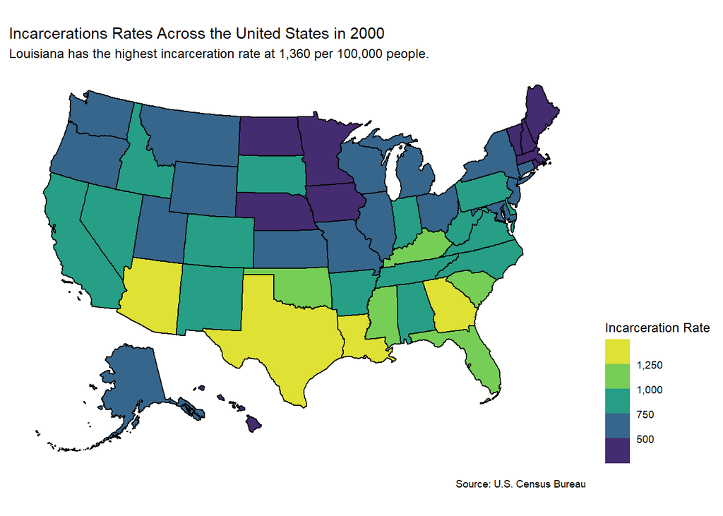

```r
# 2000 - incarceration rates map

plot_usmap(data = state_incarceration_data, values = "incarceration_rate_00", color = "black") +
  labs(title = "Incarcerations Rates Across the United States in 2000",
       subtitle = "Louisiana has the highest incarceration rate at 1,360 per 100,000 people.",
       caption = "Source: U.S. Census Bureau") +
  scale_fill_binned(type = "viridis", name = "Incarceration Rate", label = scales::comma) +
  theme(legend.position = "right", text=element_text(family="Palatino"))
```

[output not shown]

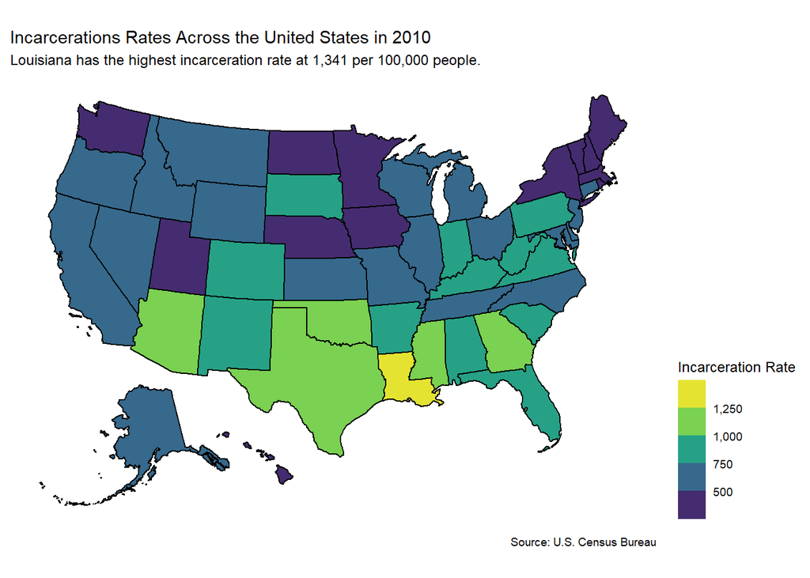

```r
# 2010 - incarceration rates map

plot_usmap(data = state_incarceration_data, values = "incarceration_rate_10", color = "black") +
  labs(title = "Incarcerations Rates Across the United States in 2010",
       subtitle = "Louisiana has the highest incarceration rate at 1,341 per 100,000 people.",
       caption = "Source: U.S. Census Bureau") +
  scale_fill_binned(type = "viridis", name = "Incarceration Rate", label = scales::comma) +
  theme(legend.position = "right", text=element_text(family="Palatino"))
```

[output not shown]

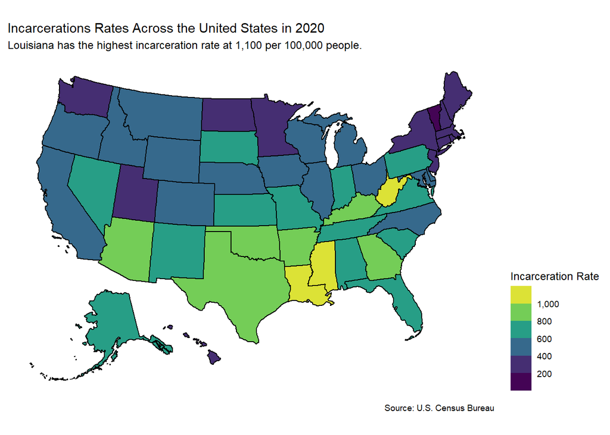

```r
# 2020 - incarceration rates map

plot_usmap(data = state_incarceration_data, values = "incarceration_rate_20", color = "black") +
  labs(title = "Incarcerations Rates Across the United States in 2020",
       subtitle = "Louisiana has the highest incarceration rate at 1,100 per 100,000 people.",
       caption = "Source: U.S. Census Bureau") +
  scale_fill_binned(type = "viridis", name = "Incarceration Rate", label = scales::comma) +
  theme(legend.position = "right", text=element_text(family="Palatino"))
```

##### Interactive Maps

```r
library(mapview)
library(leaflet)
library(leafsync)
library(leaflet.extras2)
library(htmlwidgets)

# turns data frame into a spatial object
sf_state_incarceration_data <- st_as_sf(state_incarceration_data, coords = c("longitude", "latitude"), crs = 4326)

# 2020
map2020 <- mapview(sf_state_incarceration_data, zcol = "incarceration_rate_20",
                   col.regions = RColorBrewer::brewer.pal(9, "BuPu"), alpha.regions = 1,
                   layer.name = "2020 Incarceration Rates")
# 2010
map2010 <- mapview(sf_state_incarceration_data, zcol = "incarceration_rate_10",
                   col.regions = RColorBrewer::brewer.pal(9, "BuPu"), alpha.regions = 1,
                   layer.name = "2010 Incarceration Rates")
# 2000
map2000 <- mapview(sf_state_incarceration_data, zcol = "incarceration_rate_00",
                   col.regions = RColorBrewer::brewer.pal(9, "BuPu"), alpha.regions = 1,
                   layer.name = "2000 Incarceration Rates")
# synced maps

sync(map2020, map2010, map2000)
```

[interactive chart not shown]

```r
sync(map2020, map2010)
```

[interactive chart not shown]

```r
sync(map2010, map2000)
```

[interactive chart not shown]

```r
# juxtaposed maps

map2020 | map2010
```

[interactive chart not shown]

```r
map2010 | map2000
```

[interactive chart not shown]

Before moving on to the next section, let’s take a moment to process and compare the 2020 incarceration rates for each state one more time.

Despite Louisiana being considered the “incarceration capital of the world”, the incarceration rates of other states aren’t too far behind. Pretty alarming, right?

[output not shown]

[output not shown]

[output cut: 241 more lines]

[output not shown]

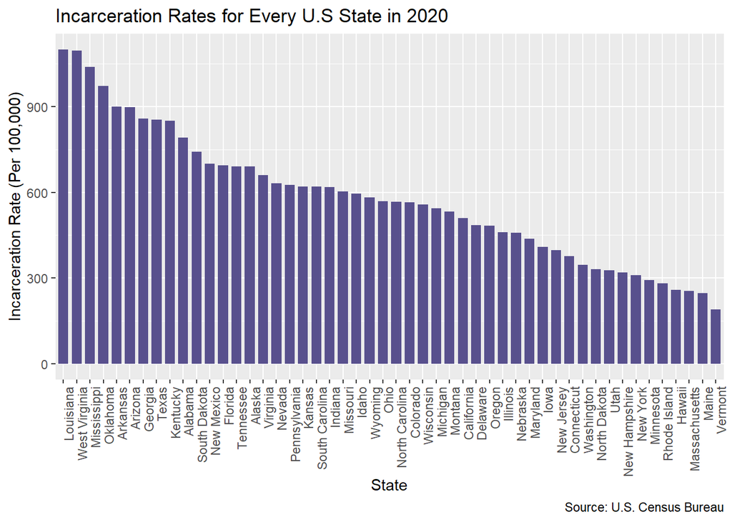

```r
# visualizing state incarceration rates

state_incarceration_data %>%
  ggplot() +
  geom_bar(aes(x=reorder(state, -incarceration_rate_20), weight=incarceration_rate_20), width=.75, fill="#58508d") +
  theme(
    axis.text.x = element_text(angle=90, hjust=1), text=element_text(family="Palatino")) +
    labs(
    title="Incarceration Rates for Every U.S State in 2020",
    x = "State",
    y = "Incarceration Rate (Per 100,000)",
    caption = "Source: U.S. Census Bureau")
```

Now that we have a better picture of what incarceration rates have looked over time across the United States, let’s continue exploring our suspicion that southern states seem to have the highest incarceration rates compared to other U.S. regions.

For this next question, we’re using the regions designated by the Census to compare 2020 incarceration rates across the four regions: northeast, midwest, west, and south.

#### 2. Which U.S. region had the highest incarceration rates in 2020?

Based on the maps generated by the code below, it looks like the Southern region of the United States has the highest incarceration rates. We can tell by looking at the legends of each map. The maps reveal that southern region is the only U.S. region with incarceration rates over 1,000 per 100,000 residents. Additionally, the south has more states with high incarceration rates compared to other regions.

> Recommended Reading: “Long Road to Nowhere: How Southern States Struggle with Long-Term Incarceration” by the Southern Poverty Law Center (https://www.splcactionfund.org/news/2021/02/24/long-road-nowhere-how-southern-states-struggle-long-term-incarceration)

It’s also important to highlight the southern region’s racial demographics. Approximately 19% of the population is Black and 18% of the population is Hispanic/Latino (https://censusreporter.org/profiles/02000US3-south-region/). In 2019, over half, roughly 56% of the United States’ Black population lives in the south, according to the Pew Research Center (https://www.pewresearch.org/social-trends/2021/03/25/the-growing-diversity-of-black-america/).

As we have already established, Black communities are incarcerated at disproportionately higher rates than white communities. Given what we now know about the southern region’s racial demographics and incarceration rates, we can see how prison gerrymandering compounds on other systemic, oppressive issues and leads to even greater discrimination against communities of color.

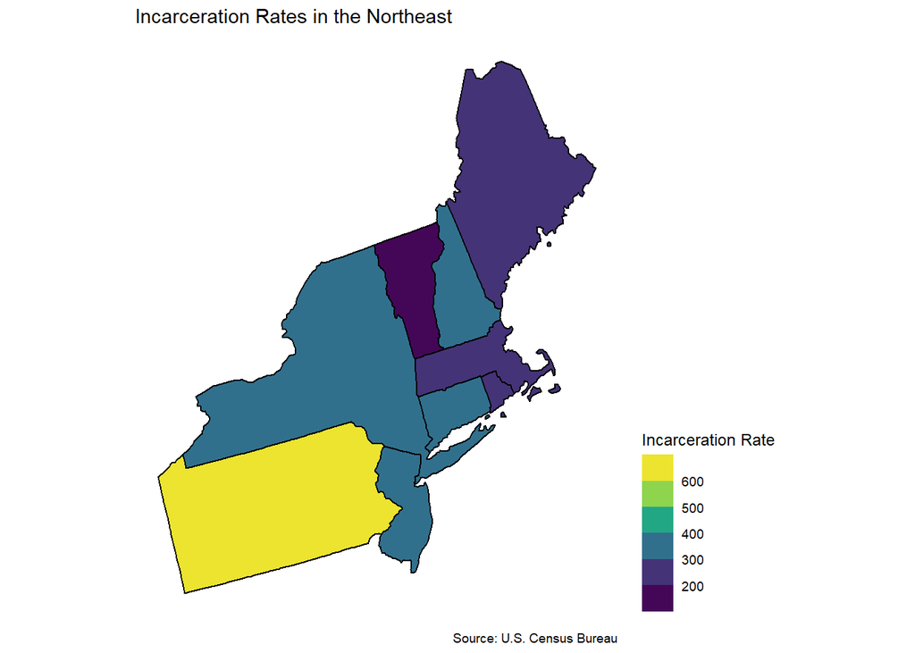

```r
# northeast

plot_usmap(include = .northeast_region, data = state_incarceration_data, values = "incarceration_rate_20", color = "black") +
    labs(
    title="Incarceration Rates in the Northeast",
    caption = "Source: U.S. Census Bureau") +
  scale_fill_binned(type = "viridis", name = "Incarceration Rate", label = scales::comma) +
  theme(legend.position = "right", text=element_text(family="Palatino"))
```

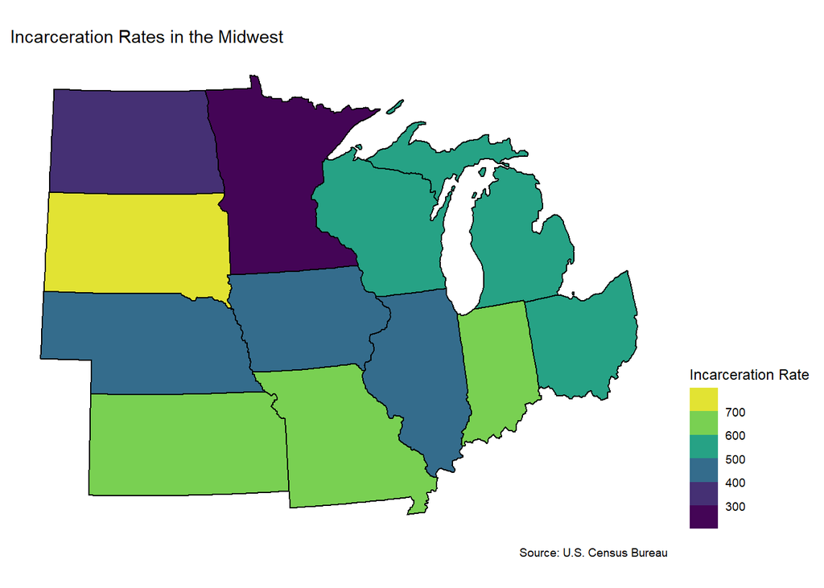

```r
# midwest

plot_usmap(include = .midwest_region, data = state_incarceration_data, values = "incarceration_rate_20", color = "black") +
    labs(
    title="Incarceration Rates in the Midwest",
    caption = "Source: U.S. Census Bureau") +
  scale_fill_binned(type = "viridis", name = "Incarceration Rate", label = scales::comma) +
  theme(legend.position = "right", text=element_text(family="Palatino"))
```

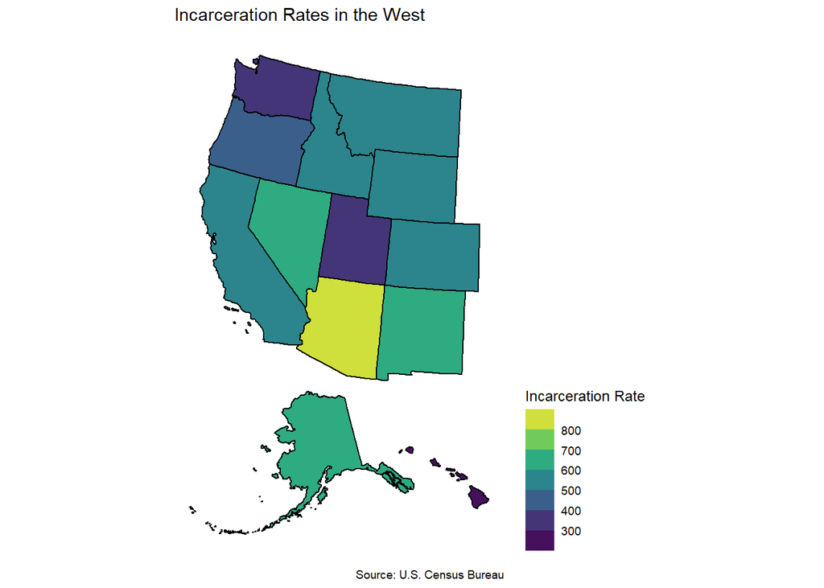

```r
# west

plot_usmap(include = .west_region, data = state_incarceration_data, values = "incarceration_rate_20", color = "black") +
    labs(
    title="Incarceration Rates in the West",
    caption = "Source: U.S. Census Bureau") +
  scale_fill_binned(type = "viridis", name = "Incarceration Rate", label = scales::comma) +
  theme(legend.position = "right", text=element_text(family="Palatino"))
```

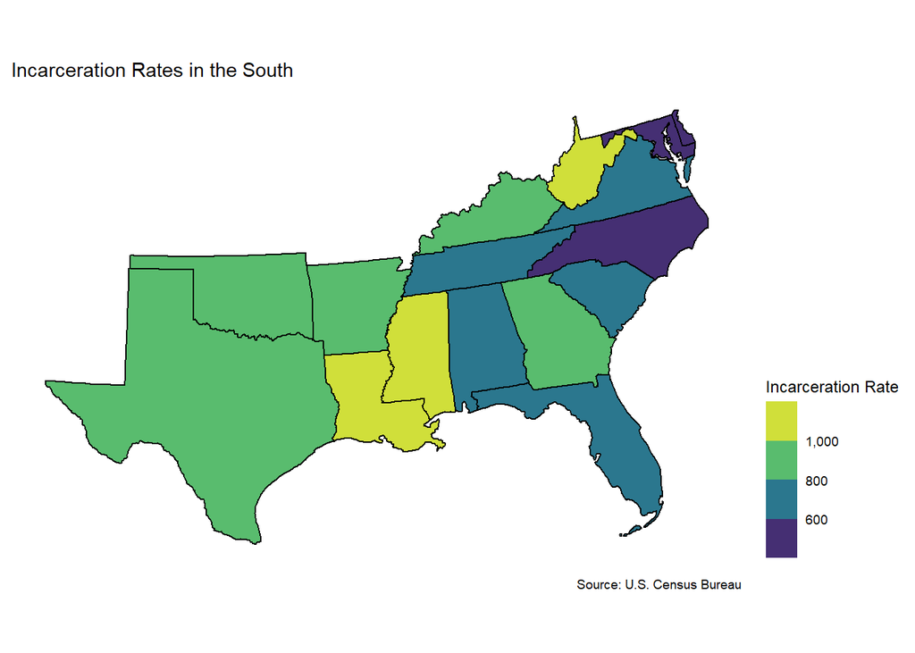

```r
# south

plot_usmap(include = .south_region, data = state_incarceration_data, values = "incarceration_rate_20", color = "black") +
    labs(
    title="Incarceration Rates in the South",
    caption = "Source: U.S. Census Bureau") +
  scale_fill_binned(type = "viridis", name = "Incarceration Rate", label = scales::comma) +
  theme(legend.position = "right", text=element_text(family="Palatino"))
```

To answer the following question, we’ll use a cleaner version of our initial dataset. This new, county-level dataset no longer has columns for state specific information. Before diving into our continued analysis of this data, we’ll add on some new columns to find the net change in incarcerated population counts since 2000.

#### 3. Which were the top five U.S. counties that saw the largest net change in incarcerated population counts since 2000? Alternatively, which were the top five U.S. counties that saw either a decrease or no change in prison population since 2000?

When toggling through each map, it’s really interesting to see how incarcerated populations have changed at a county-level nationwide over time. Between 2000 and 2010, there are fairly significant increases in incarcerated populations, especially in Pinal County, AZ.

Let’s look at Pinal County’s most recent incarcerated population data and compare it to state incarcerated population data. Using the “state_incarceration_data” data frame, we can see that in 2020, Arizona had 64,154 incarcerated people. Now looking at our “arizona” data frame, we can see that 21,631 people are incarcerated in Pinal County.

About one third or ~33% of the state’s incarcerated population is in Pinal County. Arizona Public Media found that about 22,000 incarcerated people are located in the state’s eighth district, which is much more than any other legislative district.

We’ve already established the impact prison gerrymandering can have, but this is additional proof that the populations in some U.S. counties are inflated by incarcerated populations, which strengthens the jurisdiction’s political power.

> Recommended Reading: “Where do the tens of thousands of people in Arizona’s prisons fit in redistricting?” by Andrew Oxford, Arizona Public Media (https://news.azpm.org/s/89268-where-do-the-tens-of-thousands-of-people-in-arizonas-prisons-fit-in-redistricting/)

Between 2010 and 2020, however, we see less increases and more decreases in incarcerated populations. It’s very likely that the COVID-19 pandemic is largely the reason why the number of incarcerated people across the country decreased so much.

Incarcerated people were infected by the virus at a rate five times higher than the country’s national rate, according to a July 2020 research article in the Journal of the American Medical Association (https://jamanetwork.com/journals/jama/fullarticle/2768249). The reported death rate among inmates, which the article reported as 39 deaths per 100,000, is higher than the country’s death rate of 29 deaths per 100,000.

Of the 3,133 counties in the United States, 376 counties saw no change between 2000 and 2010 and 476 counties saw no change between 2010 and 2020. While there is a lot of overlap between both, it’s difficult to say, based solely on this data, why these counties saw no change. The most plausible reason, though, is that there are simply no prisons, jails, detention centers, etc. in those jurisdictions.

##### The top five counties with the largest net change in incarcerated population counts between 2000 and 2010 were:

- Pinal County, AZ -> 11670
- Kern County, CA -> 7123
- Maricopa County, AZ -> 4861
- Sacramento County, CA -> 4208
- Clark County, NV -> 3332

##### The top five counties with the largest net change in incarcerated population counts between 2010 and 2020 were:

- Trousdale County, TN -> 2479
- Montcalm County, MI -> 2397
- Centre County, PA -> 2240
- Fulton County, GA -> 2210
- Santa Rosa County, FL -> 2169

##### The top five counties with the smallest net change in incarcerated population counts between 2000 and 2010 were:

- Hampton city, VA -> -8154
- Escambia County, FL -> -3682
- Wayne County, MI -> -3643
- Miami-Dade County, FL -> -3557
- Baldwin County, GA -> -3046

##### The top five counties with the smallest net change in incarcerated population counts between 2010 and 2020 were:

- Kern County, CA -> -8449
- Bronx County, NY -> -8261
- Los Angeles County, CA -> -6616
- Cook County, IL -> -5685
- Kings County, CA -> -5175

```r
county_incarceration_data <- read_csv("data/county_census_incarceration_data.csv")
county_incarceration_data <- county_incarceration_data %>%
  mutate(net_change_00_10 = incarcerated_10-incarcerated_00) %>%
  mutate(net_change_10_20 = incarcerated_20-incarcerated_10) %>%
  mutate(net_change_00_20 = incarcerated_20-incarcerated_00)

# net change between 2000 and 2010

county_incarceration_data %>%
  arrange(desc(net_change_00_10)) %>%
  select(state, county, net_change_00_10) %>%
  head(5)
```

```
## # A tibble: 5 × 3
##   state county            net_change_00_10
##   <chr> <chr>                        <dbl>
## 1 AZ    Pinal County                 11670
## 2 CA    Kern County                   7123
## 3 AZ    Maricopa County               4861
## 4 CA    Sacramento County             4208
## 5 NV    Clark County                  3332
```

```r
county_incarceration_data %>%
  arrange(net_change_00_10) %>%
  select(state, county, net_change_00_10) %>%
  head(5)
```

```
## # A tibble: 5 × 3
##   state county            net_change_00_10
##   <chr> <chr>                        <dbl>
## 1 VA    Hampton city                 -8154
## 2 FL    Escambia County              -3682
## 3 MI    Wayne County                 -3643
## 4 FL    Miami-Dade County            -3557
## 5 GA    Baldwin County               -3046
```

```r
no_change_00_10 <- county_incarceration_data %>%
  filter(net_change_00_10 == 0) %>%
  select(state, county, net_change_00_10)

View(no_change_00_10)

# net change between 2010 and 2020

county_incarceration_data %>%
  arrange(desc(net_change_10_20)) %>%
  select(state, county, net_change_10_20) %>%
  head(5)
```

```
## # A tibble: 5 × 3
##   state county            net_change_10_20
##   <chr> <chr>                        <dbl>
## 1 TN    Trousdale County              2479
## 2 MI    Montcalm County               2397
## 3 PA    Centre County                 2240
## 4 GA    Fulton County                 2210
## 5 FL    Santa Rosa County             2169
```

```r
county_incarceration_data %>%
  arrange(net_change_10_20) %>%
  select(state, county, net_change_10_20) %>%
  head(5)
```

```
## # A tibble: 5 × 3
##   state county             net_change_10_20
##   <chr> <chr>                         <dbl>
## 1 CA    Kern County                   -8449
## 2 NY    Bronx County                  -8261
## 3 CA    Los Angeles County            -6616
## 4 IL    Cook County                   -5685
## 5 CA    Kings County                  -5175
```

[output not shown]

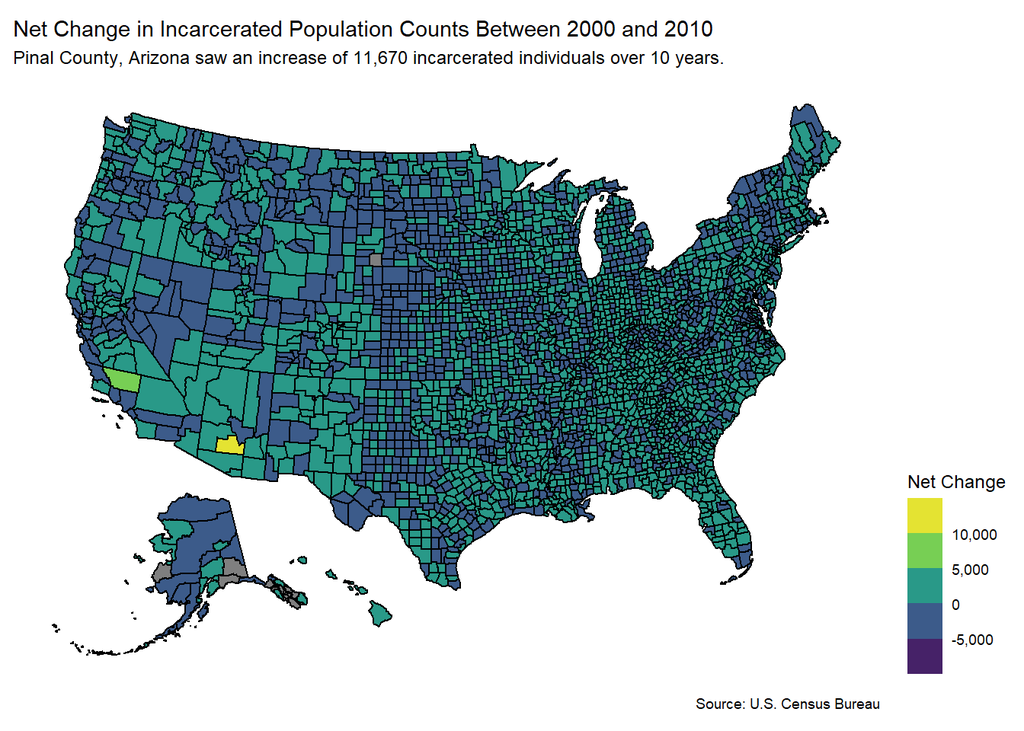

```r
no_change_10_20 <- county_incarceration_data %>%
  filter(net_change_10_20 == 0) %>%
  select(state, county, net_change_10_20)

View(no_change_10_20)

# net change maps

# 2000 and 2010

plot_usmap(regions = "counties", data = county_incarceration_data, values = "net_change_00_10", color = "black") +
  labs(title = "Net Change in Incarcerated Population Counts Between 2000 and 2010",
       subtitle = "Pinal County, Arizona saw an increase of 11,670 incarcerated individuals over 10 years.",
       caption = "Source: U.S. Census Bureau") +
  scale_fill_binned(type = "viridis", name = "Net Change", label = scales::comma) +
  theme(legend.position = "right", text=element_text(family="Palatino"))
```

[output not shown]

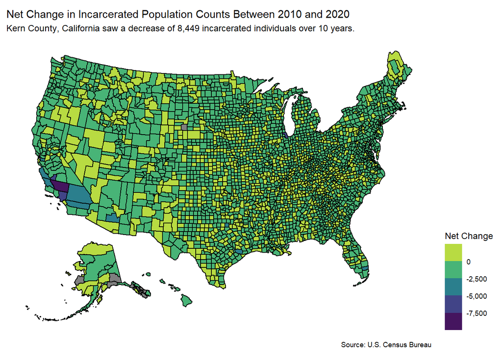

```r
# 2010 and 2020

plot_usmap(regions = "counties", data = county_incarceration_data, values = "net_change_10_20", color = "black") +
  labs(title = "Net Change in Incarcerated Population Counts Between 2010 and 2020",
       subtitle = "Kern County, California saw a decrease of 8,449 incarcerated individuals over 10 years.",
       caption = "Source: U.S. Census Bureau") +
  scale_fill_binned(type = "viridis", name = "Net Change", label = scales::comma) +
  theme(legend.position = "right", text=element_text(family="Palatino"))
```

Now, let’s look at what percentage makes up the incarcerated population in each state and compare it to figures from 2010 and 2000.

#### 4. For each U.S. state, roughly how much (%) of the state’s adult population was incarcerated/being held in a correctional facility in 2020? Compare it to figures from 2010 and 2000.

Using the maps generated in the code block below, we can see how much of a state’s population is incarcerated. Although the percentages are very small, they represent tens of thousands of people.

When toggled, the maps show that the prison population across the country decreased slightly in 2020. Louisiana, again, remains almost untouched over time, which confirms our previous findings about the state’s high incarceration rates. We can also see how the southern region of the United States appears to have the most incarcerated individuals compared to other regions.

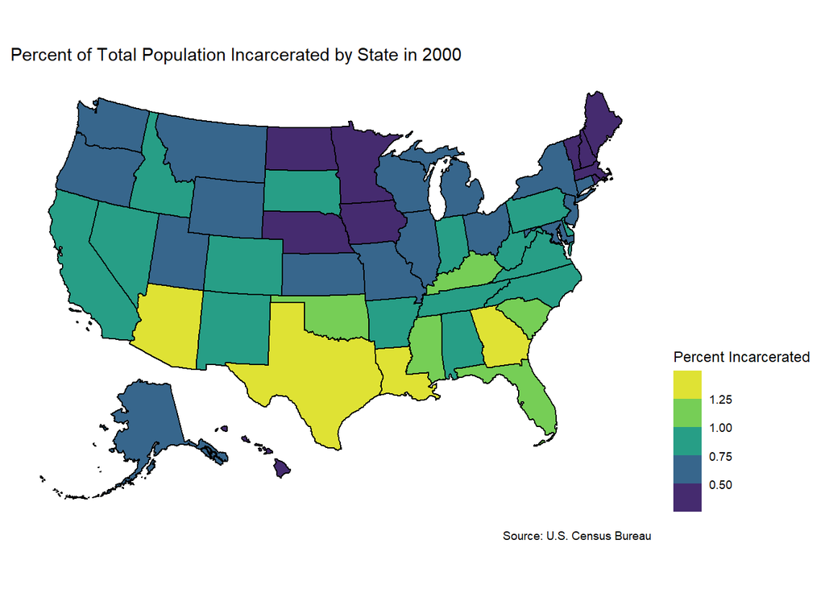

```r
# 2000

plot_usmap(data = state_incarceration_data, values = "pct_incarcerated_00", color = "black") +
  labs(title = "Percent of Total Population Incarcerated by State in 2000",
       caption = "Source: U.S. Census Bureau") +
  scale_fill_binned(type = "viridis", name = "Percent Incarcerated", label = scales::comma) +
  theme(legend.position = "right", text=element_text(family="Palatino"))
```

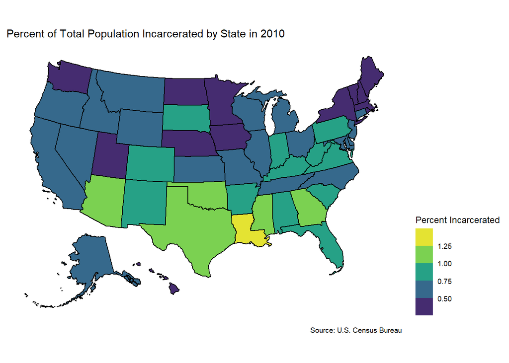

```r
# 2010

plot_usmap(data = state_incarceration_data, values = "pct_incarcerated_10", color = "black") +
  labs(title = "Percent of Total Population Incarcerated by State in 2010",
       caption = "Source: U.S. Census Bureau") +
  scale_fill_binned(type = "viridis", name = "Percent Incarcerated", label = scales::comma) +
  theme(legend.position = "right", text=element_text(family="Palatino"))
```

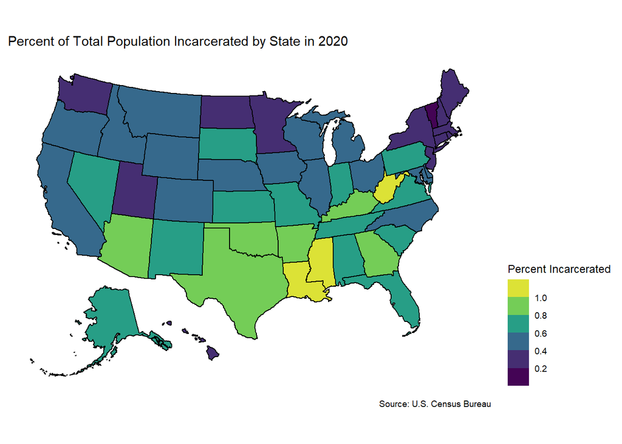

```r
# 2020

plot_usmap(data = state_incarceration_data, values = "pct_incarcerated_20", color = "black") +
  labs(title = "Percent of Total Population Incarcerated by State in 2020",
       caption = "Source: U.S. Census Bureau") +
  scale_fill_binned(type = "viridis", name = "Percent Incarcerated", label = scales::comma) +
  theme(legend.position = "right", text=element_text(family="Palatino"))
```

#### 5. Using ACS data, compare median household incomes and incarceration rates for Colorado, Louisiana, and Arizona in 2020.

For this final question, we’re looking at the states – Colorado, Louisiana, and Arizona – where we have found some evidence of prison gerrymandering in previous questions. Using ACS data, we’ll extract the county-level median income estimates for each state and compare them to the county-level incarceration rates.

The maps reveal that counties with the highest incarceration rates tend to have median household incomes ranging from about $50,000-60,000 a year. While this doesn’t fully tell us whether these variables are related, it opens up an opportunity for further investigation and analysis.

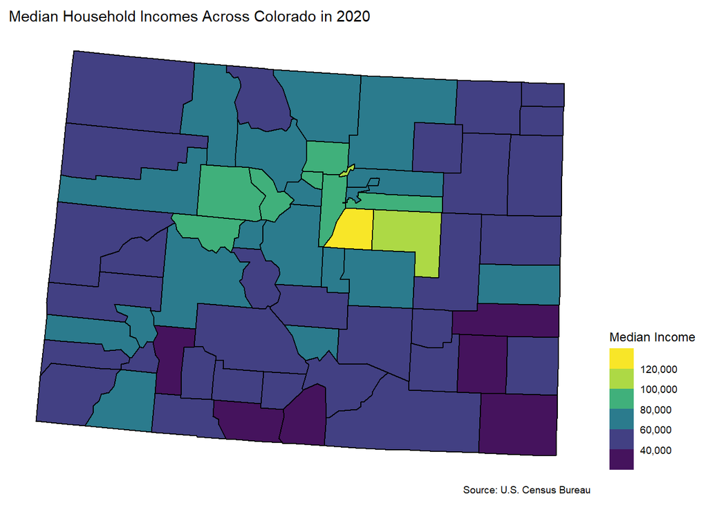

```r
# load ACS variables

acs_variables <- load_variables(year = 2020,
                      dataset = "acs5",
                      cache = TRUE)

# load median income estimates for Colorado, Pennsylvania, Mississippi, Louisiana, and Georgia

colorado_medincome <- get_acs(geography = "county",
              variables = c(medincome = "B19013_001"),
              state = "CO",
              year = 2020)
louisiana_medincome <- get_acs(geography = "county",
              variables = c(medincome = "B19013_001"),
              state = "LA",
              year = 2020)
arizona_medincome <- get_acs(geography = "county",
              variables = c(medincome = "B19013_001"),
              state = "AZ",
              year = 2020)
# clean ACS data frames to prepare for mapping

colorado_medincome <- colorado_medincome %>%
  rename(county = NAME) %>%
  rename(fips = GEOID) %>%
  mutate(county = (str_remove_all(county,", Colorado")))

louisiana_medincome <- louisiana_medincome %>%
  rename(county = NAME) %>%
  rename(fips = GEOID) %>%
  mutate(county = (str_remove_all(county,", Louisiana")))

arizona_medincome <- arizona_medincome %>%
  rename(county = NAME) %>%
  rename(fips = GEOID) %>%
  mutate(county = (str_remove_all(county,", Arizona")))

# load incarceration rates for Colorado, Louisiana, and Arizona

colorado_incarcerations <- county_incarceration_data %>%
  filter(state == "CO") %>%
  select(state, county, fips, percent_incarcerated_20)

louisiana_incarcerations <- county_incarceration_data %>%
  filter(state == "LA") %>%
  select(state, county, fips, percent_incarcerated_20)

arizona_incarcerations <- county_incarceration_data %>%
  filter(state == "AZ") %>%
  select(state, county, fips, percent_incarcerated_20)

# maps

# colorado median incomes
plot_usmap("counties", include = "CO", color = "black", data = colorado_medincome, values = "estimate") +
  labs(title = "Median Household Incomes Across Colorado in 2020",
       caption = "Source: U.S. Census Bureau") +
  scale_fill_binned(type = "viridis", name = "Median Income", label = scales::comma) +
  theme(legend.position = "right", text=element_text(family="Palatino"))
```

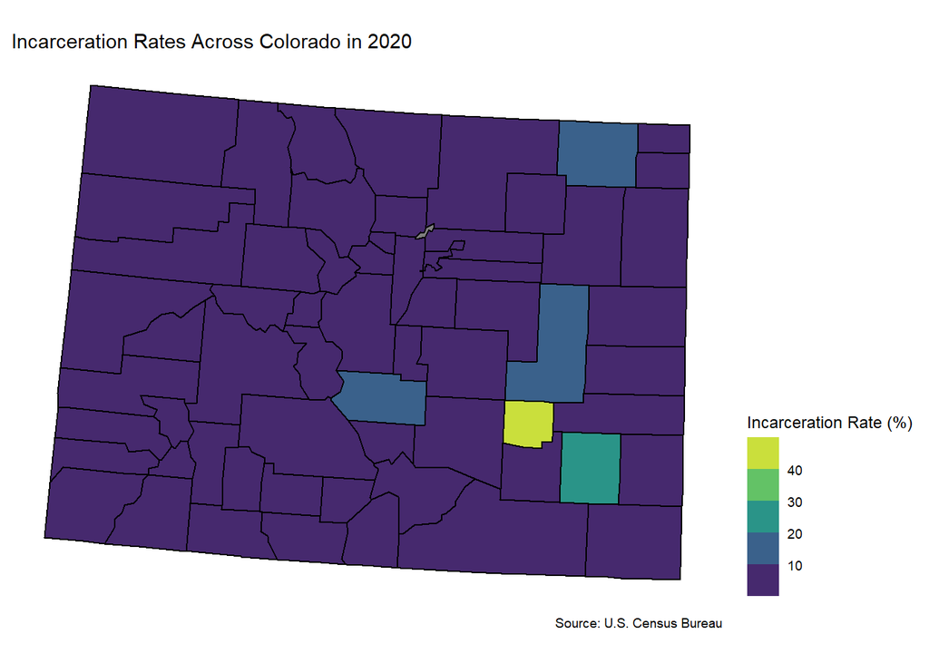

```r
# colorado incarceration rates
plot_usmap("counties", include = "CO", color = "black", data = colorado_incarcerations, values = "percent_incarcerated_20") +
  labs(title = "Incarceration Rates Across Colorado in 2020",
       caption = "Source: U.S. Census Bureau") +
  scale_fill_binned(type = "viridis", name = "Incarceration Rate (%)", label = scales::comma) +
  theme(legend.position = "right", text=element_text(family="Palatino"))
```

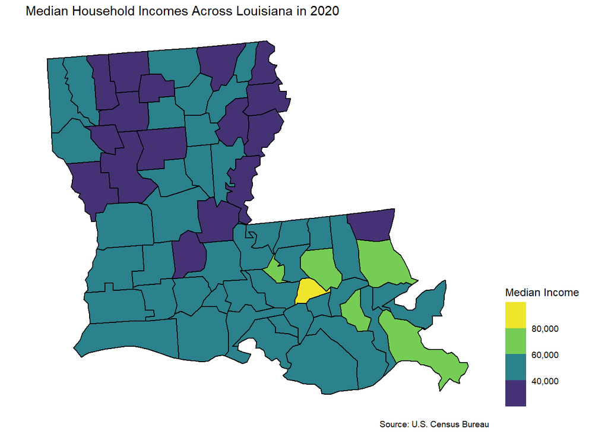

```r
# louisiana median incomes
plot_usmap("counties", include = "LA", color = "black", data = louisiana_medincome, values = "estimate") +
  labs(title = "Median Household Incomes Across Louisiana in 2020",
       caption = "Source: U.S. Census Bureau") +
  scale_fill_binned(type = "viridis", name = "Median Income", label = scales::comma) +
  theme(legend.position = "right", text=element_text(family="Palatino"))
```

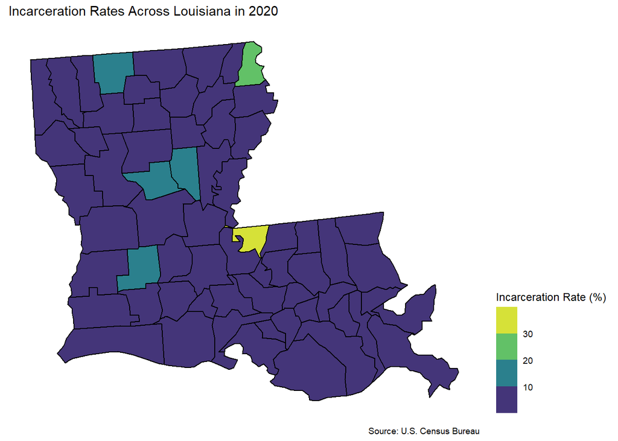

```r
# louisiana incarceration rates
plot_usmap("counties", include = "LA", color = "black", data = louisiana_incarcerations, values = "percent_incarcerated_20") +
  labs(title = "Incarceration Rates Across Louisiana in 2020",
       caption = "Source: U.S. Census Bureau") +
  scale_fill_binned(type = "viridis", name = "Incarceration Rate (%)", label = scales::comma) +
  theme(legend.position = "right", text=element_text(family="Palatino"))
```

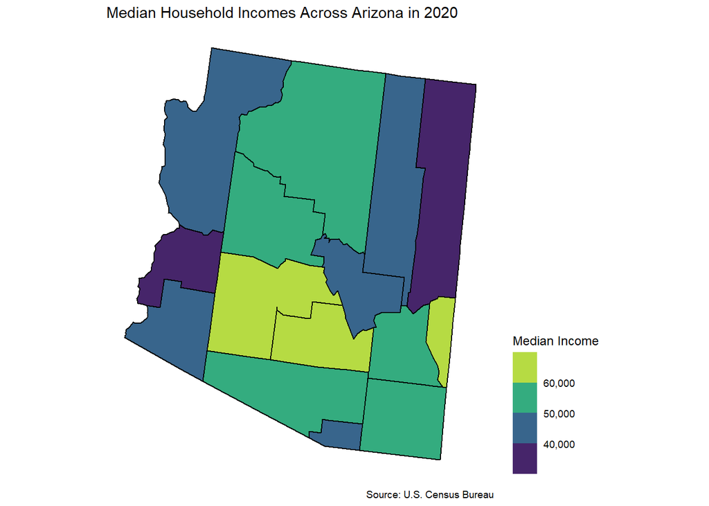

```r
# arizona median incomes
plot_usmap("counties", include = "AZ", color = "black", data = arizona_medincome, values = "estimate") +
  labs(title = "Median Household Incomes Across Arizona in 2020",
       caption = "Source: U.S. Census Bureau") +
  scale_fill_binned(type = "viridis", name = "Median Income", label = scales::comma) +
  theme(legend.position = "right", text=element_text(family="Palatino"))
```

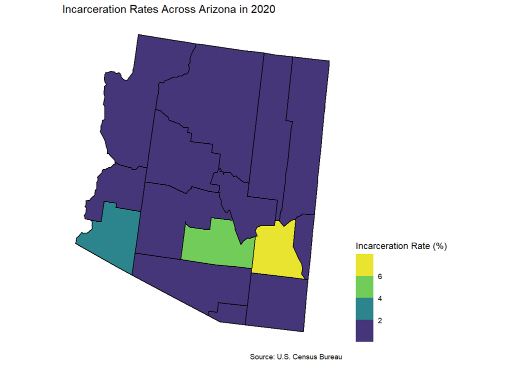

```r
# arizona incarceration rates
plot_usmap("counties", include = "AZ", color = "black", data = arizona_incarcerations, values = "percent_incarcerated_20") +
  labs(title = "Incarceration Rates Across Arizona in 2020",
       caption = "Source: U.S. Census Bureau") +
  scale_fill_binned(type = "viridis", name = "Incarceration Rate (%)", label = scales::comma) +
  theme(legend.position = "right", text=element_text(family="Palatino"))
```

#### Summary

Redistricting remains a hot-button issue nationwide as midterm election season nears and it’s a powerful process with lasting impacts. Prison gerrymandering, however, which is a product of cruel, oppressive systems in this country, really shows us just how deep discrimination can go.

Many incarcerated individuals are stripped of their right to vote, which makes it even harder for an already oppressed minority to contribute to politics.

In its entirety, this notebook aims to educate others on prison gerrymandering and reveal patterns in government data that reinforces the lived experiences of incarcerated individuals. Although this notebook is truly just the tip of the iceberg when it comes to prison gerrymandering, it highlights inequities that would otherwise be hidden without the help of data analysis.